# Question 1: with t-1 variable

Mary Fisher

February 28; Updated March 13

#### Research Question: Which oceanographic and herbivory conditions are important for predicting giant kelp size and abundance?

**Response variables:** Giant kelp mean abundance, max abundance; Giant kelp mean size, maximum size.

**Predictor variables:**

1. Urchin abundance: Sea urchins are herbivores, and in large numbers (also called “herds”) can decimate kelp forests. We have three measures of urchin abundance - red urchin abundance, purple urchin abundance, and urchin abundance across all species.
2. Water chemistry: Like any algae / plant, kelp requires nutrients to grow. We have measurements for the following nutrients: nitrogen, ammonia, urea, and phosphorus. We also have chlorophyl concentrations, which is a general index of primary productivity.
3. Water temperature: All species have a thermal range, or a range of temperatures, at which they grow best; the degree of variability in temperature can also have an impact on growth. With kelp forest loss from recent marine heatwaves and long-term warming, there has been much interest in whether kelp are impacted by an absolute temperature threshold, or by the degree of variability in temperature. We have mean summer and mean winter temperatures, and variation in summer and mean winter temperatures.
4. Giant kelp mean / max abundance, mean / max size at t-1: This data set is a time series, so the giant kelp response variable at a given site for year `t` should be dependent on giant kelp condition in year `t-1`.

**Modeling approach:** OLS incorporating previous size / abundance.

# Prepare Data

Read in data

```r
mydat <- read.csv(here::here("data","kelp_prediction_data_complete.csv")) %>%
  clean_names()
head(mydat)
```

```
##   year month site mapy_mean_density mapy_mean_count mapy_mean_fronds
## 1 2002     8 CARP         0.2125000          17.000        10.250000
## 2 2002     8 NAPL         0.0859375           6.875         3.654545
## 3 2003     8 AQUE         0.3250000          26.000        36.487179
## 4 2003     8 CARP         0.1859375          14.875         9.201681
## 5 2003     8 NAPL         0.4437500          35.500        14.602113
## 6 2004     7 AQUE         0.2562500          20.500        20.146341
##   mapy_max_fronds mapy_mean_hld mapy_max_hld franciscanus_abundance
## 1              54      16.20909           66              6.7500000
## 2              18      22.55000           40             15.8750000
## 3             189      58.35256          210              0.8333333
## 4              42      22.31959           57              6.7500000
## 5              95      37.42199          110              7.7500000
## 6             194      51.02459          196              0.1666667
##   purpuratus_abundance urchin_abundance max_ammonia max_no2_no3 max_po4
```

[output cut: 27 more lines]

Add in the giant kelp response variables for `t-1`.

```
##
## There are 0 missing measurements for the previous year's kelp abundance.
```

```
##  [1] "year"                   "month"                  "site"
##  [4] "mapy_mean_density"      "mapy_mean_count"        "mapy_mean_fronds"
##  [7] "mapy_max_fronds"        "mapy_mean_hld"          "mapy_max_hld"
## [10] "franciscanus_abundance" "purpuratus_abundance"   "urchin_abundance"
## [13] "max_ammonia"            "max_no2_no3"            "max_po4"
## [16] "max_poc"                "max_pon"                "max_tchl"
## [19] "mean_ammonia"           "mean_no2_no3"           "mean_po4"
## [22] "mean_poc"               "mean_pon"               "mean_tchl"
## [25] "summer_mean_temp"       "summer_var_temp"        "winter_mean_temp"
## [28] "winter_var_temp"        "prev_mean_density"      "prev_mean_count"
## [31] "prev_mean_fronds"       "prev_max_fronds"        "prev_mean_hld"
## [34] "prev_max_hld"
```

## Predictor Variables

### Herbivory

We have three variables that quantify urchin abundance - we’ll just work with total abundance (`urchin_abundance`).

This variable is zero-inflated, a common problem with ecological count data. So I’m going to split it into two predictor variables - a categorical presence / absence variable, and then an abundance variable.

First, get rid of the species-specific counts

```r
lmdat <- dplyr::select(mydat, -purpuratus_abundance,-franciscanus_abundance)
```

Then grab the total abundance data and split it into the two new variables. Does the square root transformation of the urchin abundance variable look normal?

```r
lmdat <- lmdat %>%
  mutate(urchin_presence = ifelse(urchin_abundance > 0, 1, 0),
         urchin_abundance = ifelse(urchin_abundance==0,0,sqrt(urchin_abundance)))
```

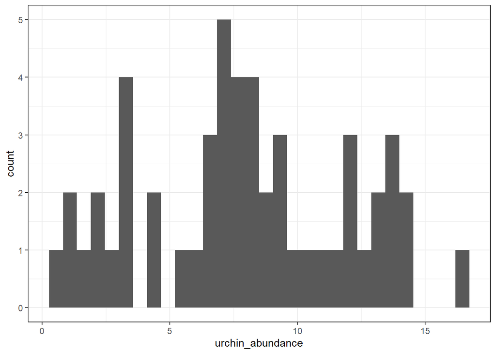

```
##
##  Shapiro-Wilk normality test
##
## data:  lmdat$urchin_abundance
## W = 0.92871, p-value = 0.001061
```

### Water Chemistry

The maximum values of water chemistry estimates were very difficult to force into a normal distribution. So I’m only going to work with the mean values.

```r
lmdat <- lmdat %>%
  dplyr::select(-max_ammonia,-max_no2_no3,-max_po4,-max_poc,-max_pon,-max_tchl)
colnames(lmdat)
```

```
##  [1] "year"              "month"             "site"
##  [4] "mapy_mean_density" "mapy_mean_count"   "mapy_mean_fronds"
##  [7] "mapy_max_fronds"   "mapy_mean_hld"     "mapy_max_hld"
## [10] "urchin_abundance"  "mean_ammonia"      "mean_no2_no3"
## [13] "mean_po4"          "mean_poc"          "mean_pon"
## [16] "mean_tchl"         "summer_mean_temp"  "summer_var_temp"
## [19] "winter_mean_temp"  "winter_var_temp"   "prev_mean_density"
## [22] "prev_mean_count"   "prev_mean_fronds"  "prev_max_fronds"
## [25] "prev_mean_hld"     "prev_max_hld"      "urchin_presence"
```

### Multicolinearity

Let’s ignore the previous kelp size / abundance for now.

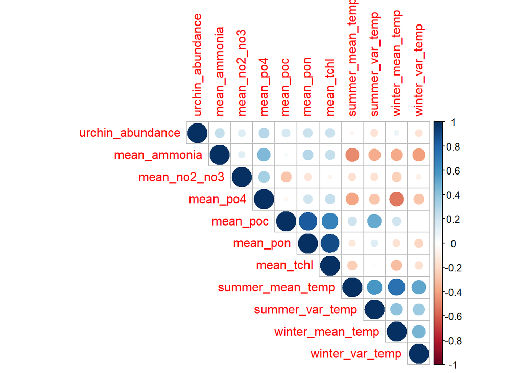

Summer and winter temperatures are correlated; since kelp is a cold-water species, we’ll stick with summer temperature only. I’ll rely on variable selection to remove either mean or variance in temperature, which are also correlated with each other.

```r
lmdat <- lmdat %>%
  dplyr::select(-winter_mean_temp,-winter_var_temp)
```

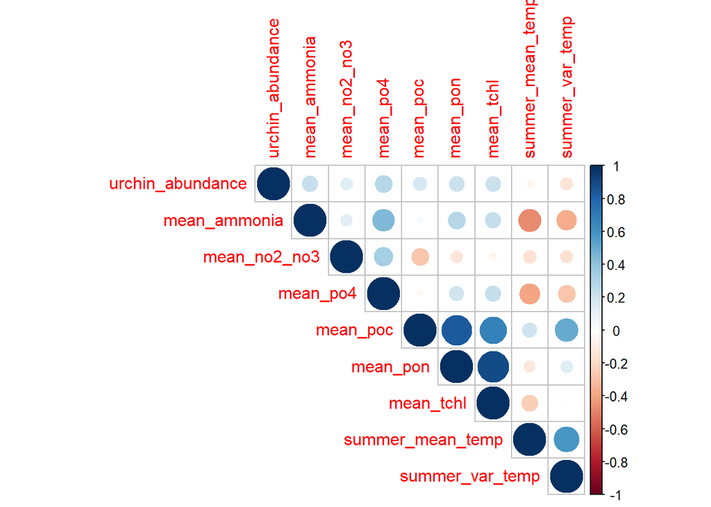

Particulate organic carbon (`poc`) is highly correlated with particulate organic nitrogen and mean total chlorophyll. I’ll remove particulate organic carbon.

```r
lmdat <- lmdat %>%
  dplyr::select(-mean_poc)
```

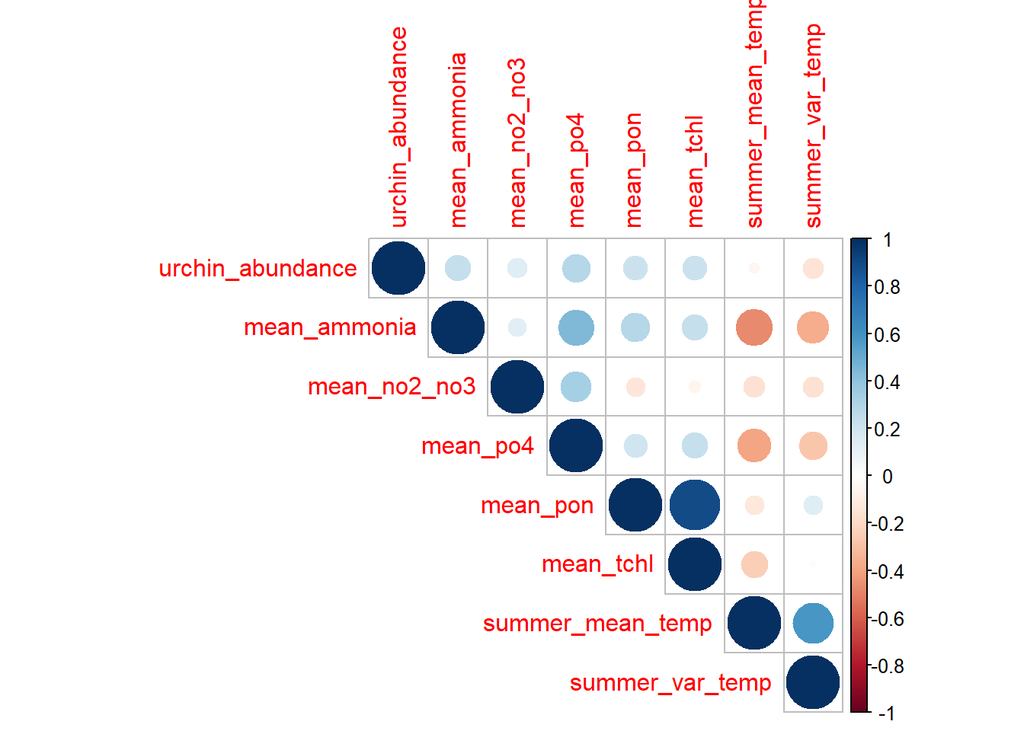

I think that for the remaining correlations, I’ll see what happens in stepwise model selection. These are the final variables:

```
##  [1] "year"              "month"             "site"
##  [4] "mapy_mean_density" "mapy_mean_count"   "mapy_mean_fronds"
##  [7] "mapy_max_fronds"   "mapy_mean_hld"     "mapy_max_hld"
## [10] "urchin_abundance"  "mean_ammonia"      "mean_no2_no3"
## [13] "mean_po4"          "mean_pon"          "mean_tchl"
## [16] "summer_mean_temp"  "summer_var_temp"   "prev_mean_density"
## [19] "prev_mean_count"   "prev_mean_fronds"  "prev_max_fronds"
## [22] "prev_mean_hld"     "prev_max_hld"      "urchin_presence"
```

### Transform variables

According to the script [04_explore_predictors](https://github.com/mfisher5/504_BiodivSB/tree/master/scripts), many of the predictor variables are not normally distributed.

```r
lmdat.t <- lmdat %>%
  mutate(summer_var_temp = log(summer_var_temp),
         mean_pon= log(mean_pon),
         mean_tchl= log(mean_tchl))
```

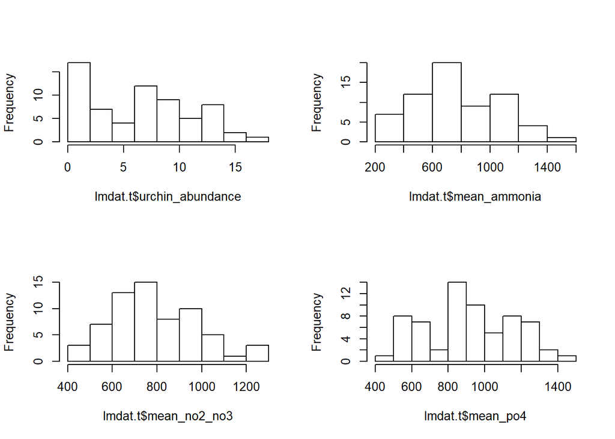

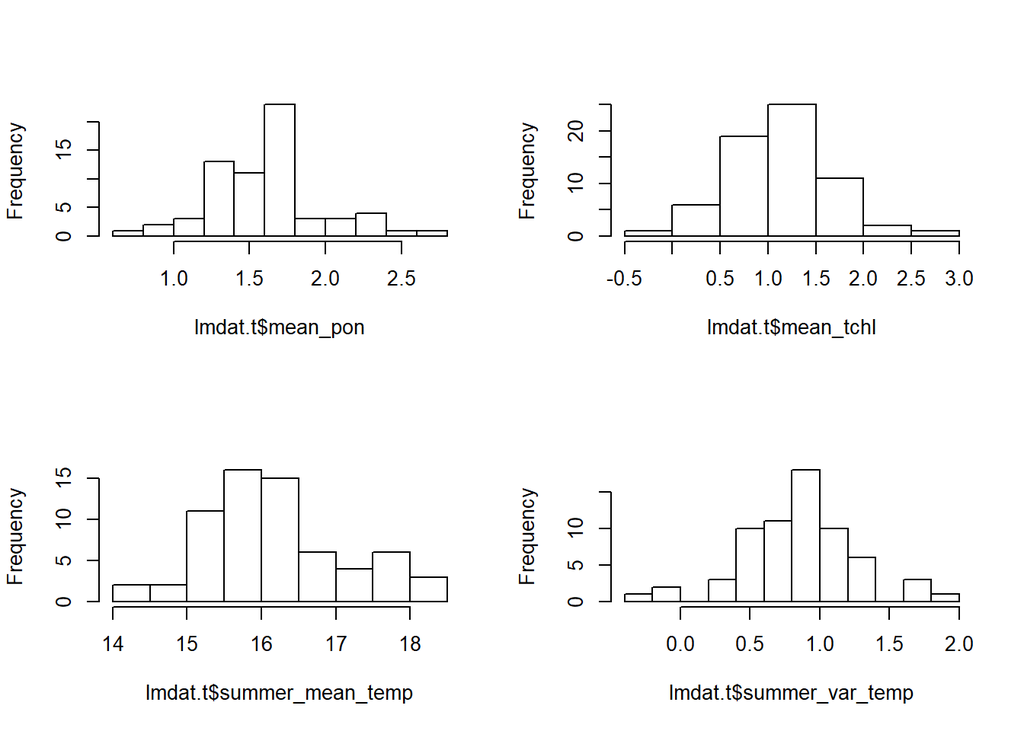

## Response Variables

Mean holdfast diameter is normal (yay!).

Mean density and mean number of fronds need to be log-transformed. I think that means that I can just run a generalized linear model using the `family=Gamma(link='log')` argument.

But I do need to run the variable transformation for the previous mean density / fronds

```r
lmdat.t <- lmdat.t %>%
  mutate(prev_mean_density = log(prev_mean_density),
         prev_mean_count = log(prev_mean_count),
         prev_mean_fronds = log(prev_mean_fronds))
```

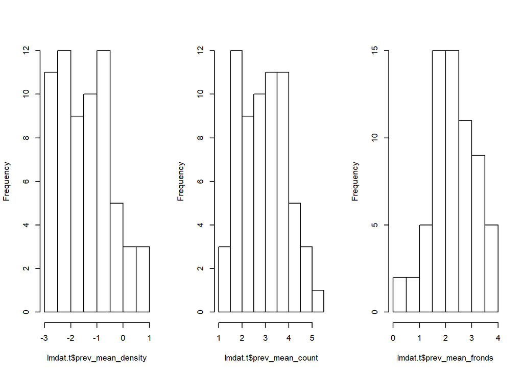

Maximum number of fronds and holdfast diameter need a square root transformation. For the response variable, this means that I can just run a generalized linear model using `family=Gamma(link='sqrt')`.

But I do need to transform the previous fronds and holdfast diameter.

```r
lmdat.t <- lmdat.t %>%
  mutate(prev_max_fronds = sqrt(prev_max_fronds),
         prev_max_hld = sqrt(prev_max_hld))
```

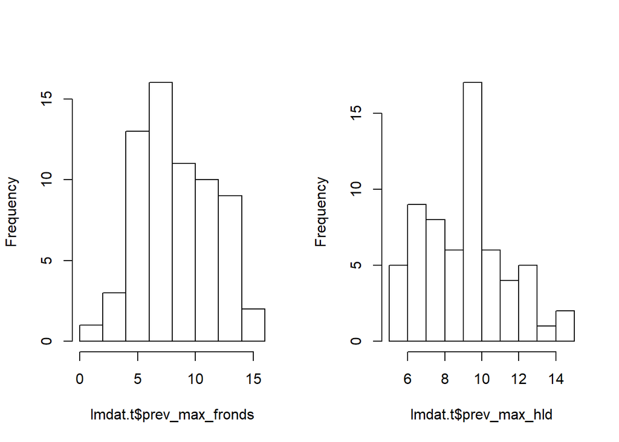

So now I have the following variables:

```
##  [1] "year"              "month"             "site"
##  [4] "mapy_mean_density" "mapy_mean_count"   "mapy_mean_fronds"
##  [7] "mapy_max_fronds"   "mapy_mean_hld"     "mapy_max_hld"
## [10] "urchin_abundance"  "mean_ammonia"      "mean_no2_no3"
## [13] "mean_po4"          "mean_pon"          "mean_tchl"
## [16] "summer_mean_temp"  "summer_var_temp"   "prev_mean_density"
## [19] "prev_mean_count"   "prev_mean_fronds"  "prev_max_fronds"
## [22] "prev_mean_hld"     "prev_max_hld"      "urchin_presence"
```

# Model Selection

## Kelp Abundance

*Response:* log(`mapy_mean_density`)

Interactions: site by previous mean density

Since there are some missing data in the kelp size categories, I’m going to select only the variables we are interested in at the moment

### LM

Model Type: OLS, Log transformation of response

#### Model Selection: BIC

Backward model selection

```
## Start:  AIC=-3.63
## log(mapy_mean_density) ~ site + urchin_presence + urchin_abundance +
##     prev_mean_density + site:prev_mean_density + mean_ammonia +
##     mean_no2_no3 + mean_po4 + mean_tchl + mean_pon + summer_mean_temp +
##     summer_var_temp
##
##
## Step:  AIC=-3.63
## log(mapy_mean_density) ~ site + urchin_abundance + prev_mean_density +
##     mean_ammonia + mean_no2_no3 + mean_po4 + mean_tchl + mean_pon +
##     summer_mean_temp + summer_var_temp + site:prev_mean_density
##
##                          Df Sum of Sq    RSS      AIC
## - site:prev_mean_density  4   0.56768 19.914 -18.4510
## - mean_pon                1   0.01242 19.359  -7.7660
## - summer_var_temp         1   0.01634 19.363  -7.7528
## - mean_ammonia            1   0.17320 19.520  -7.2284
## - mean_tchl               1   0.22766 19.574  -7.0473
## - mean_po4                1   0.33078 19.677  -6.7057
## - summer_mean_temp        1   1.01654 20.363  -4.4790
## - mean_no2_no3            1   1.16737 20.514  -3.9993
## <none>                                19.346  -3.6333
## - urchin_abundance        1   2.10261 21.449  -1.1015
##
## Step:  AIC=-18.45
## log(mapy_mean_density) ~ site + urchin_abundance + prev_mean_density +
##     mean_ammonia + mean_no2_no3 + mean_po4 + mean_tchl + mean_pon +
##     summer_mean_temp + summer_var_temp
##
##                     Df Sum of Sq    RSS     AIC
## - mean_pon           1    0.0069 19.921 -22.603
## - summer_var_temp    1    0.0187 19.933 -22.564
## - mean_tchl          1    0.2024 20.116 -21.968
## - mean_ammonia       1    0.3873 20.301 -21.373
## - mean_po4           1    0.4906 20.405 -21.043
## - site               4    4.8939 24.808 -20.866
## - prev_mean_density  1    1.1734 21.087 -18.904
## - summer_mean_temp   1    1.1922 21.106 -18.846
## - mean_no2_no3       1    1.2444 21.159 -18.686
## <none>                           19.914 -18.451
```

[output cut: 86 more lines]

```
##     summer_mean_temp
##
##                     Df Sum of Sq    RSS     AIC
## - urchin_abundance   1    0.1568 28.841 -40.295
## <none>                           28.684 -36.475
## - summer_mean_temp   1    6.0782 34.762 -28.157
## - prev_mean_density  1   14.5348 43.219 -14.004
##
## Step:  AIC=-40.29
## log(mapy_mean_density) ~ prev_mean_density + summer_mean_temp
##
##                     Df Sum of Sq    RSS     AIC
## <none>                           28.841 -40.295
## - summer_mean_temp   1    5.9773 34.818 -32.227
## - prev_mean_density  1   15.3937 44.235 -16.668
```

Forward Model Selection

```
## Start:  AIC=-8.13
## log(mapy_mean_density) ~ 1
##
##                     Df Sum of Sq    RSS     AIC
## + prev_mean_density  1   18.9728 34.818 -32.227
## + urchin_presence    1   13.5781 40.213 -22.864
## + summer_mean_temp   1    9.5564 44.235 -16.668
## + site               4   16.1521 37.639 -14.640
## <none>                           53.791  -8.129
## + summer_var_temp    1    2.2683 51.523  -6.755
## + mean_po4           1    1.5719 52.219  -5.882
## + mean_no2_no3       1    1.5321 52.259  -5.833
## + mean_pon           1    0.7938 52.997  -4.921
## + urchin_abundance   1    0.7789 53.012  -4.902
## + mean_tchl          1    0.1593 53.632  -4.147
## + mean_ammonia       1    0.0409 53.750  -4.004
##
## Step:  AIC=-32.23
## log(mapy_mean_density) ~ prev_mean_density
##
##                    Df Sum of Sq    RSS     AIC
## + summer_mean_temp  1    5.9773 28.841 -40.295
## + urchin_presence   1    3.1518 31.667 -34.220
## + mean_po4          1    2.8021 32.016 -33.506
## <none>                          34.818 -32.227
## + summer_var_temp   1    1.2615 33.557 -30.451
## + mean_ammonia      1    1.2073 33.611 -30.346
## + mean_no2_no3      1    0.3243 34.494 -28.661
## + mean_tchl         1    0.1094 34.709 -28.257
## + urchin_abundance  1    0.0560 34.762 -28.157
## + mean_pon          1    0.0033 34.815 -28.059
## + site              4    4.2683 30.550 -24.030
##
## Step:  AIC=-40.29
## log(mapy_mean_density) ~ prev_mean_density + summer_mean_temp
##
##                    Df Sum of Sq    RSS     AIC
## + urchin_presence   1   2.55796 26.283 -42.157
## <none>                          28.841 -40.295
## + mean_no2_no3      1   1.09120 27.750 -38.628
## + mean_tchl         1   0.68444 28.157 -37.682
## + mean_po4          1   0.52110 28.320 -37.306
## + mean_pon          1   0.27649 28.565 -36.747
## + urchin_abundance  1   0.15681 28.684 -36.475
## + mean_ammonia      1   0.04207 28.799 -36.215
## + summer_var_temp   1   0.03376 28.807 -36.197
## + site              4   3.03180 25.809 -30.817
##
## Step:  AIC=-42.16
## log(mapy_mean_density) ~ prev_mean_density + summer_mean_temp +
##     urchin_presence
##
##                    Df Sum of Sq    RSS     AIC
## <none>                          26.283 -42.157
## + urchin_abundance  1   1.01773 25.265 -40.550
## + mean_no2_no3      1   0.96946 25.314 -40.426
## + mean_po4          1   0.53004 25.753 -39.307
## + mean_tchl         1   0.24207 26.041 -38.584
## + mean_pon          1   0.12933 26.154 -38.304
## + mean_ammonia      1   0.03145 26.252 -38.061
## + summer_var_temp   1   0.00013 26.283 -37.983
## + site              3   0.47384 25.809 -30.817
```

Forward and backward selection produces slightly different models. The R-squared is better when including the variable `urchin presence`, and that variable is significant.

```
##
## Call:
## lm(formula = log(mapy_mean_density) ~ prev_mean_density + summer_mean_temp +
##     urchin_presence, data = abund_dat)
##
## Residuals:
##      Min       1Q   Median       3Q      Max
## -1.29036 -0.37072 -0.08427  0.26865  1.67149
##
## Coefficients:
##                   Estimate Std. Error t value Pr(>|t|)
## (Intercept)       -6.16536    1.41309  -4.363 5.03e-05 ***
## prev_mean_density  0.39992    0.09811   4.076 0.000135 ***
## summer_mean_temp   0.30202    0.08544   3.535 0.000785 ***
## urchin_presence1   0.57080    0.23427   2.437 0.017762 *
## ---
## Signif. codes:  0 '***' 0.001 '**' 0.01 '*' 0.05 '.' 0.1 ' ' 1
##
## Residual standard error: 0.6564 on 61 degrees of freedom
## Multiple R-squared:  0.5114, Adjusted R-squared:  0.4874
## F-statistic: 21.28 on 3 and 61 DF,  p-value: 1.493e-09
```

```
##
## Call:
## lm(formula = log(mapy_mean_density) ~ prev_mean_density + summer_mean_temp,
##     data = abund_dat)
##
## Residuals:
##      Min       1Q   Median       3Q      Max
## -1.39702 -0.39869 -0.08252  0.32307  1.69218
##
## Coefficients:
##                   Estimate Std. Error t value Pr(>|t|)
## (Intercept)       -5.79262    1.45964  -3.969 0.000190 ***
## prev_mean_density  0.51458    0.08945   5.753  2.9e-07 ***
## summer_mean_temp   0.31738    0.08854   3.585 0.000665 ***
## ---
## Signif. codes:  0 '***' 0.001 '**' 0.01 '*' 0.05 '.' 0.1 ' ' 1
##
## Residual standard error: 0.682 on 62 degrees of freedom
## Multiple R-squared:  0.4638, Adjusted R-squared:  0.4465
## F-statistic: 26.82 on 2 and 62 DF,  p-value: 4.058e-09
```

Model Diagnostics

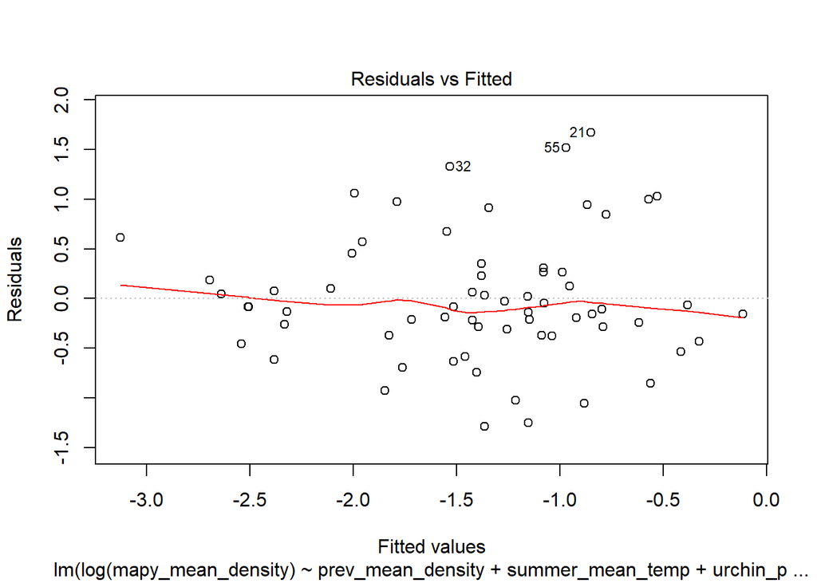

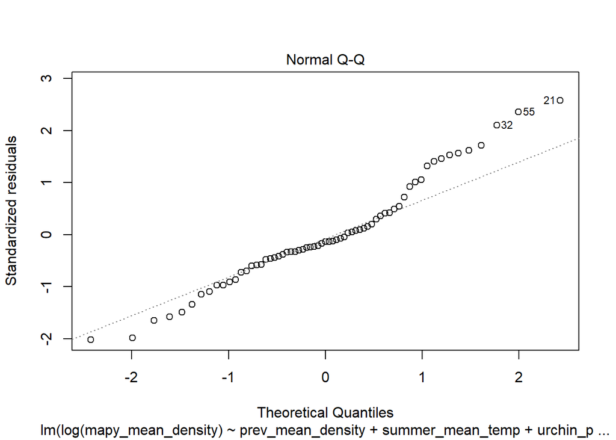

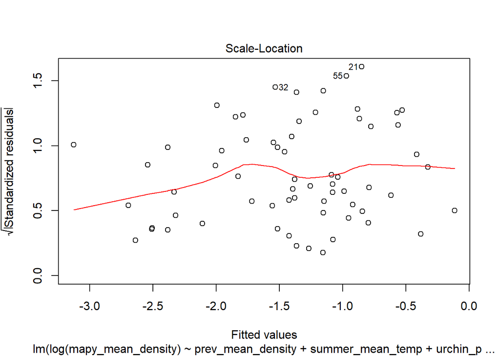

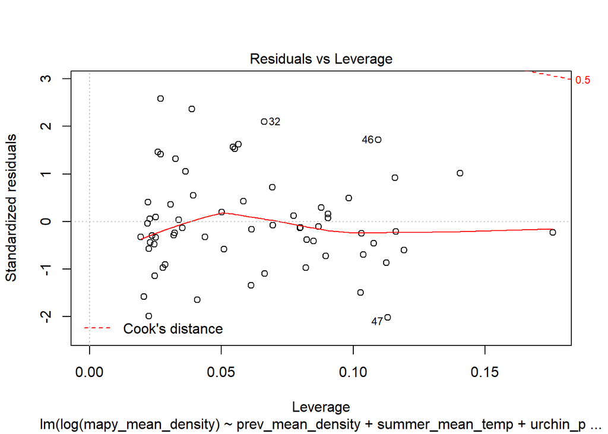

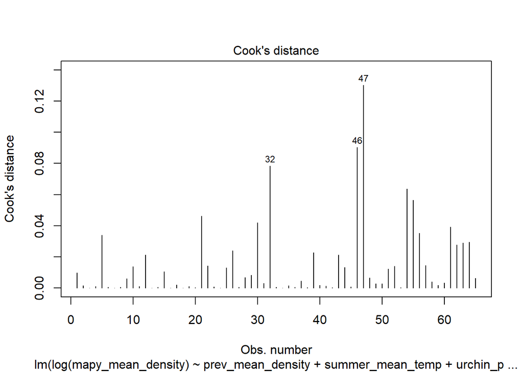

Even with the log-transformation of the response variable, there is still some non-normality of the residuals.

#### Model Selection: AIC

Backward model selection

```
## Start:  AIC=-42.77
## log(mapy_mean_density) ~ site + urchin_presence + urchin_abundance +
##     prev_mean_density + site:prev_mean_density + mean_ammonia +
##     mean_no2_no3 + mean_po4 + mean_tchl + mean_pon + summer_mean_temp +
##     summer_var_temp
##
##
## Step:  AIC=-42.77
## log(mapy_mean_density) ~ site + urchin_abundance + prev_mean_density +
##     mean_ammonia + mean_no2_no3 + mean_po4 + mean_tchl + mean_pon +
##     summer_mean_temp + summer_var_temp + site:prev_mean_density
##
##                          Df Sum of Sq    RSS     AIC
## - site:prev_mean_density  4   0.56768 19.914 -48.892
## - mean_pon                1   0.01242 19.359 -44.731
## - summer_var_temp         1   0.01634 19.363 -44.717
## - mean_ammonia            1   0.17320 19.520 -44.193
## - mean_tchl               1   0.22766 19.574 -44.012
## - mean_po4                1   0.33078 19.677 -43.670
## <none>                                19.346 -42.772
## - summer_mean_temp        1   1.01654 20.363 -41.444
## - mean_no2_no3            1   1.16737 20.514 -40.964
## - urchin_abundance        1   2.10261 21.449 -38.066
##
## Step:  AIC=-48.89
## log(mapy_mean_density) ~ site + urchin_abundance + prev_mean_density +
##     mean_ammonia + mean_no2_no3 + mean_po4 + mean_tchl + mean_pon +
##     summer_mean_temp + summer_var_temp
##
##                     Df Sum of Sq    RSS     AIC
## - mean_pon           1    0.0069 19.921 -50.870
## - summer_var_temp    1    0.0187 19.933 -50.831
## - mean_tchl          1    0.2024 20.116 -50.235
## - mean_ammonia       1    0.3873 20.301 -49.640
## - mean_po4           1    0.4906 20.405 -49.310
## <none>                           19.914 -48.892
## - prev_mean_density  1    1.1734 21.087 -47.171
## - summer_mean_temp   1    1.1922 21.106 -47.113
## - mean_no2_no3       1    1.2444 21.159 -46.953
## - urchin_abundance   1    2.3668 22.281 -43.593
```

[output cut: 45 more lines]

```
## - urchin_abundance   1    2.3972 22.754 -48.227
## - site               4    4.9215 25.278 -47.388
##
## Step:  AIC=-54.12
## log(mapy_mean_density) ~ site + urchin_abundance + prev_mean_density +
##     mean_no2_no3 + mean_tchl + summer_mean_temp
##
##                     Df Sum of Sq    RSS     AIC
## <none>                           20.781 -54.122
## - mean_tchl          1    0.9125 21.694 -53.329
## - mean_no2_no3       1    1.0949 21.876 -52.785
## - prev_mean_density  1    1.5511 22.332 -51.443
## - summer_mean_temp   1    2.8393 23.620 -47.798
## - urchin_abundance   1    3.2573 24.038 -46.658
## - site               4    6.1639 26.945 -45.238
```

Forward Model Selection

```
## Start:  AIC=-10.3
## log(mapy_mean_density) ~ 1
##
##                     Df Sum of Sq    RSS     AIC
## + prev_mean_density  1   18.9728 34.818 -36.576
## + urchin_presence    1   13.5781 40.213 -27.213
## + site               4   16.1521 37.639 -25.512
## + summer_mean_temp   1    9.5564 44.235 -21.017
## + summer_var_temp    1    2.2683 51.523 -11.103
## <none>                           53.791 -10.303
## + mean_po4           1    1.5719 52.219 -10.231
## + mean_no2_no3       1    1.5321 52.259 -10.181
## + mean_pon           1    0.7938 52.997  -9.269
## + urchin_abundance   1    0.7789 53.012  -9.251
## + mean_tchl          1    0.1593 53.632  -8.496
## + mean_ammonia       1    0.0409 53.750  -8.353
##
## Step:  AIC=-36.58
## log(mapy_mean_density) ~ prev_mean_density
##
##                    Df Sum of Sq    RSS     AIC
## + summer_mean_temp  1    5.9773 28.841 -46.818
## + urchin_presence   1    3.1518 31.667 -40.743
## + mean_po4          1    2.8021 32.016 -40.029
## + site              4    4.2683 30.550 -37.076
## + summer_var_temp   1    1.2615 33.557 -36.974
## + mean_ammonia      1    1.2073 33.611 -36.870
## <none>                          34.818 -36.576
## + mean_no2_no3      1    0.3243 34.494 -35.184
## + mean_tchl         1    0.1094 34.709 -34.780
## + urchin_abundance  1    0.0560 34.762 -34.680
## + mean_pon          1    0.0033 34.815 -34.582
##
## Step:  AIC=-46.82
## log(mapy_mean_density) ~ prev_mean_density + summer_mean_temp
##
##                    Df Sum of Sq    RSS     AIC
## + urchin_presence   1   2.55796 26.283 -50.855
## + mean_no2_no3      1   1.09120 27.750 -47.325
## <none>                          28.841 -46.818
```

[output cut: 60 more lines]

```
## + mean_ammonia            1   0.26160 21.432 -52.118
## + site:prev_mean_density  4   0.58969 21.104 -47.120
##
## Step:  AIC=-54.12
## log(mapy_mean_density) ~ prev_mean_density + summer_mean_temp +
##     urchin_presence + urchin_abundance + mean_no2_no3 + site +
##     mean_tchl
##
##                          Df Sum of Sq    RSS     AIC
## <none>                                20.781 -54.122
## + mean_po4                1   0.42424 20.357 -53.463
## + mean_ammonia            1   0.33066 20.451 -53.165
## + mean_pon                1   0.04772 20.733 -52.272
## + summer_var_temp         1   0.03630 20.745 -52.236
## + site:prev_mean_density  4   0.91993 19.861 -49.065
```

Forward and backward selection produces *almost* the same model. Since `urchin presence` doesn’t really affect the R-squared or the MSE, I’m going to choose the simpler model from the backward selection.

```
##
## Call:
## lm(formula = log(mapy_mean_density) ~ prev_mean_density + summer_mean_temp +
##     urchin_presence + urchin_abundance + mean_no2_no3 + site +
##     mean_tchl, data = abund_dat)
##
## Residuals:
##      Min       1Q   Median       3Q      Max
## -1.14935 -0.36910 -0.03289  0.33844  1.45842
##
## Coefficients: (1 not defined because of singularities)
##                     Estimate Std. Error t value Pr(>|t|)
## (Intercept)       -7.0330485  1.7951345  -3.918 0.000249 ***
## prev_mean_density  0.2140566  0.1056467   2.026 0.047610 *
## summer_mean_temp   0.2778794  0.1013694   2.741 0.008240 **
## urchin_presence1   1.5426623  0.4276965   3.607 0.000669 ***
## urchin_abundance  -0.1148611  0.0391202  -2.936 0.004844 **
## mean_no2_no3       0.0007352  0.0004319   1.702 0.094348 .
## siteAQUE          -0.9953866  0.4249807  -2.342 0.022819 *
## siteCARP           0.3494025  0.2829036   1.235 0.222059
## siteMOHK           0.1569879  0.2415444   0.650 0.518440
## siteNAPL                  NA         NA      NA       NA
## mean_tchl          0.2963031  0.1906682   1.554 0.125914
## ---
## Signif. codes:  0 '***' 0.001 '**' 0.01 '*' 0.05 '.' 0.1 ' ' 1
##
## Residual standard error: 0.6147 on 55 degrees of freedom
## Multiple R-squared:  0.6137, Adjusted R-squared:  0.5505
## F-statistic: 9.707 on 9 and 55 DF,  p-value: 1.057e-08
```

```
##
## Call:
## lm(formula = log(mapy_mean_density) ~ site + urchin_abundance +
##     prev_mean_density + mean_no2_no3 + mean_tchl + summer_mean_temp,
##     data = abund_dat)
##
## Residuals:
##      Min       1Q   Median       3Q      Max
## -1.14935 -0.36910 -0.03289  0.33844  1.45842
##
## Coefficients:
##                     Estimate Std. Error t value Pr(>|t|)
## (Intercept)       -7.0330485  1.7951345  -3.918 0.000249 ***
## siteAQUE           0.5472757  0.3807169   1.437 0.156245
## siteCARP           1.8920648  0.5854660   3.232 0.002080 **
## siteMOHK           1.6996502  0.4329646   3.926 0.000243 ***
## siteNAPL           1.5426623  0.4276965   3.607 0.000669 ***
## urchin_abundance  -0.1148611  0.0391202  -2.936 0.004844 **
## prev_mean_density  0.2140566  0.1056467   2.026 0.047610 *
## mean_no2_no3       0.0007352  0.0004319   1.702 0.094348 .
## mean_tchl          0.2963031  0.1906682   1.554 0.125914
## summer_mean_temp   0.2778794  0.1013694   2.741 0.008240 **
## ---
## Signif. codes:  0 '***' 0.001 '**' 0.01 '*' 0.05 '.' 0.1 ' ' 1
##
## Residual standard error: 0.6147 on 55 degrees of freedom
## Multiple R-squared:  0.6137, Adjusted R-squared:  0.5505
## F-statistic: 9.707 on 9 and 55 DF,  p-value: 1.057e-08
```

Model Diagnostics

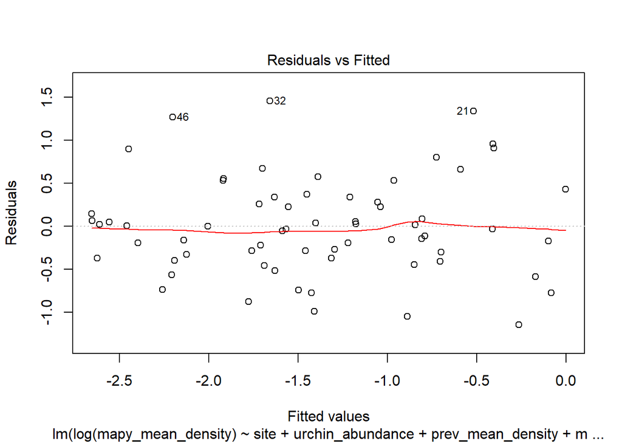

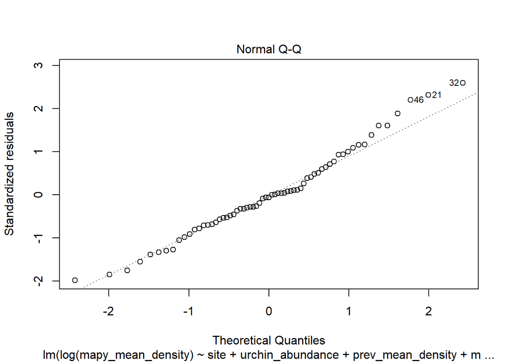

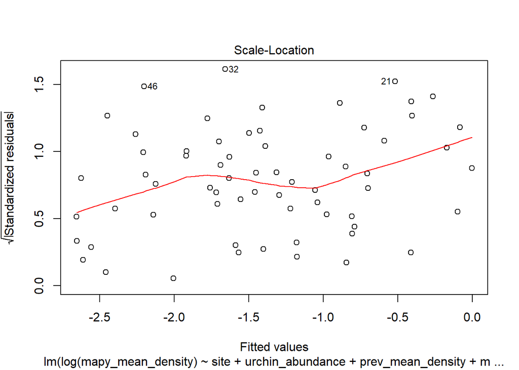

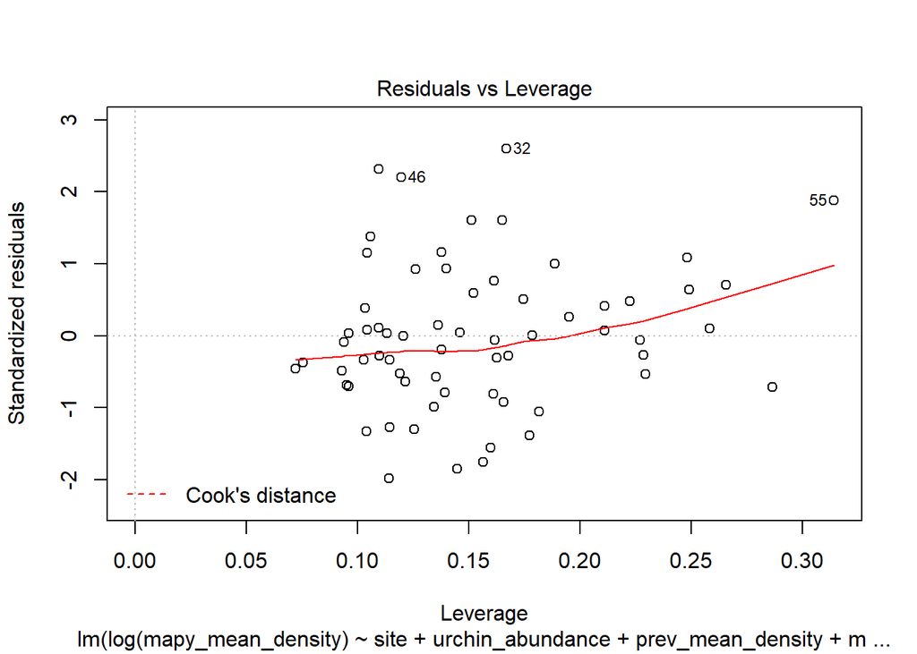

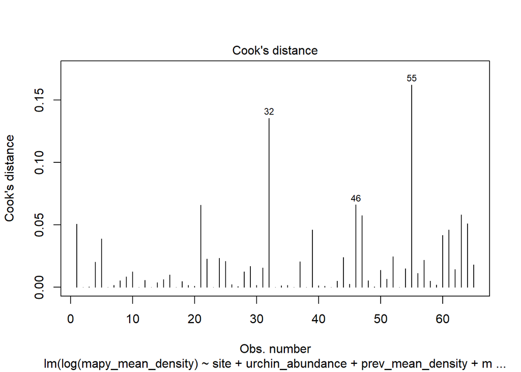

Everything looks good!

### GLM

Model Type: GLM, `family=Gamma(link='log')`

#### Model Selection: BIC

Backward Selection

```
## Start:  AIC=8.83
## mapy_mean_density ~ site + urchin_presence + urchin_abundance +
##     mean_ammonia + mean_no2_no3 + mean_po4 + mean_tchl + mean_pon +
##     summer_mean_temp + summer_var_temp + prev_mean_density +
##     site:prev_mean_density
##
##
## Step:  AIC=8.83
## mapy_mean_density ~ site + urchin_abundance + mean_ammonia +
##     mean_no2_no3 + mean_po4 + mean_tchl + mean_pon + summer_mean_temp +
##     summer_var_temp + prev_mean_density + site:prev_mean_density
##
##                          Df Deviance     AIC
## - site:prev_mean_density  4   21.209 -6.8614
## - summer_var_temp         1   20.687  4.6821
## - mean_pon                1   20.716  4.7376
## - mean_po4                1   20.784  4.8642
## - mean_ammonia            1   20.860  5.0065
## - mean_tchl               1   21.344  5.9147
## - mean_no2_no3            1   21.566  6.3313
## - summer_mean_temp        1   22.431  7.9526
## <none>                        20.672  8.8292
## - urchin_abundance        1   23.458  9.8787
##
## Step:  AIC=-6.11
## mapy_mean_density ~ site + urchin_abundance + mean_ammonia +
##     mean_no2_no3 + mean_po4 + mean_tchl + mean_pon + summer_mean_temp +
##     summer_var_temp + prev_mean_density
##
##                     Df Deviance      AIC
## - site               4   26.856 -11.6273
## - summer_var_temp    1   21.214 -10.2773
## - mean_pon           1   21.276 -10.1561
## - mean_po4           1   21.483  -9.7458
## - mean_ammonia       1   21.702  -9.3107
## - mean_tchl          1   21.800  -9.1167
## - mean_no2_no3       1   22.139  -8.4466
## - prev_mean_density  1   22.426  -7.8770
## - summer_mean_temp   1   23.088  -6.5657
## <none>                   21.209  -6.1131
```

[output cut: 86 more lines]

```
## mapy_mean_density ~ mean_no2_no3 + summer_mean_temp + prev_mean_density
##
##                     Df Deviance      AIC
## - mean_no2_no3       1   31.292 -25.9896
## <none>                   30.145 -23.5372
## - summer_mean_temp   1   37.152 -17.1995
## - prev_mean_density  1   44.778  -5.7595
##
## Step:  AIC=-25.1
## mapy_mean_density ~ summer_mean_temp + prev_mean_density
##
##                     Df Deviance      AIC
## <none>                   31.292 -25.0950
## - summer_mean_temp   1   38.723 -18.3491
## - prev_mean_density  1   47.070  -6.0826
```

Forward Selection

```
## Start:  AIC=9.68
## mapy_mean_density ~ 1
##
##                     Df Deviance     AIC
## + prev_mean_density  1   38.723 -0.3749
## + urchin_presence    1   44.305  3.9658
## + summer_mean_temp   1   47.070  6.1159
## <none>                   57.024  9.6813
## + mean_no2_no3       1   53.657 11.2379
## + summer_var_temp    1   56.603 13.5283
## + mean_pon           1   56.897 13.7573
## + mean_po4           1   56.911 13.7679
## + urchin_abundance   1   56.982 13.8236
## + mean_ammonia       1   57.005 13.8413
## + mean_tchl          1   57.009 13.8441
## + site               4   41.417 14.2426
##
## Step:  AIC=-14.21
## mapy_mean_density ~ prev_mean_density
##
##                    Df Deviance      AIC
## + summer_mean_temp  1   31.292 -18.3226
## <none>                  38.723 -14.2137
## + urchin_presence   1   36.077 -12.9890
## + mean_ammonia      1   37.057 -11.8974
## + mean_no2_no3      1   37.152 -11.7908
## + mean_po4          1   37.443 -11.4663
## + mean_tchl         1   37.966 -10.8837
## + summer_var_temp   1   38.201 -10.6215
## + mean_pon          1   38.263 -10.5529
## + urchin_abundance  1   38.721 -10.0420
## + site              4   33.925  -2.8649
##
## Step:  AIC=-25.1
## mapy_mean_density ~ prev_mean_density + summer_mean_temp
##
##                    Df Deviance     AIC
## <none>                  31.293 -25.095
## + urchin_presence   1   28.573 -24.917
## + mean_no2_no3      1   30.145 -22.608
## + summer_var_temp   1   30.684 -21.815
## + mean_tchl         1   30.823 -21.611
## + urchin_abundance  1   30.936 -21.444
## + mean_pon          1   31.098 -21.206
## + mean_ammonia      1   31.122 -21.171
## + mean_po4          1   31.243 -20.994
## + site              4   27.518 -13.944
```

Forward and backward selection chose the same model

```
##
## Call:
## glm(formula = mapy_mean_density ~ summer_mean_temp + prev_mean_density,
##     family = Gamma(link = "log"), data = abund_dat)
##
## Deviance Residuals:
##     Min       1Q   Median       3Q      Max
## -1.2908  -0.5904  -0.3391   0.1288   1.8269
##
## Coefficients:
##                   Estimate Std. Error t value Pr(>|t|)
## (Intercept)        -5.9962     1.7654  -3.397  0.00120 **
## summer_mean_temp    0.3487     0.1071   3.257  0.00183 **
## prev_mean_density   0.5584     0.1082   5.162 2.74e-06 ***
## ---
## Signif. codes:  0 '***' 0.001 '**' 0.01 '*' 0.05 '.' 0.1 ' ' 1
##
## (Dispersion parameter for Gamma family taken to be 0.6804697)
##
##     Null deviance: 57.024  on 64  degrees of freedom
## Residual deviance: 31.292  on 62  degrees of freedom
## AIC: -31.618
##
## Number of Fisher Scoring iterations: 6
```

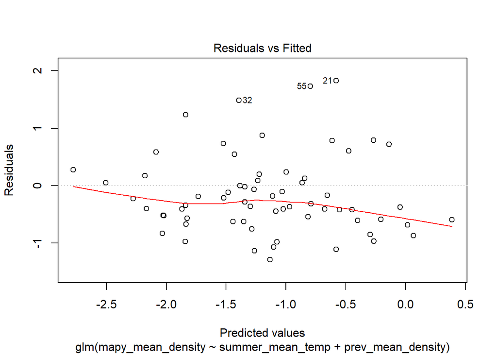

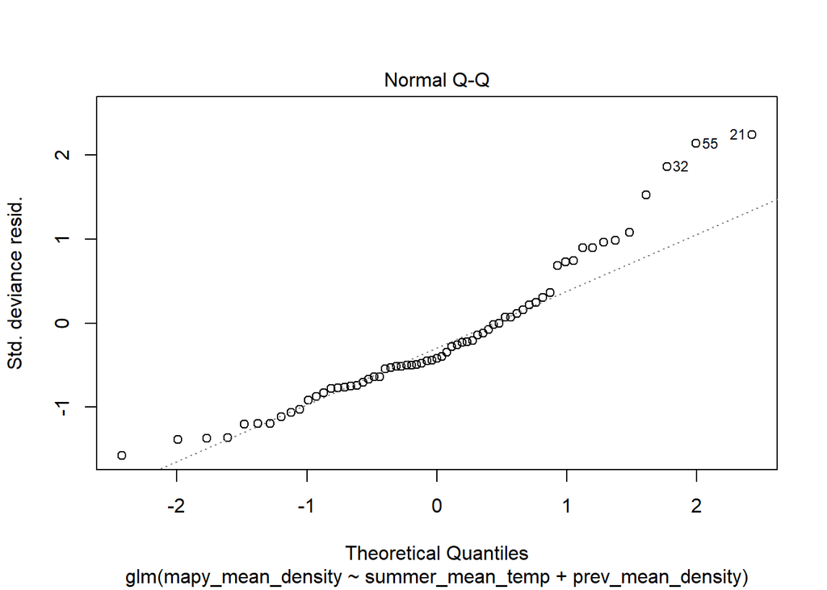

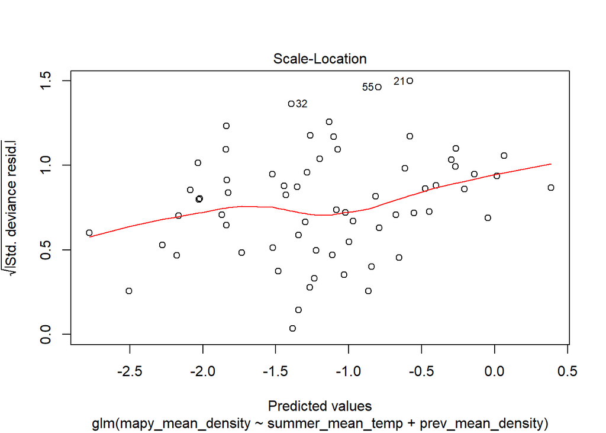

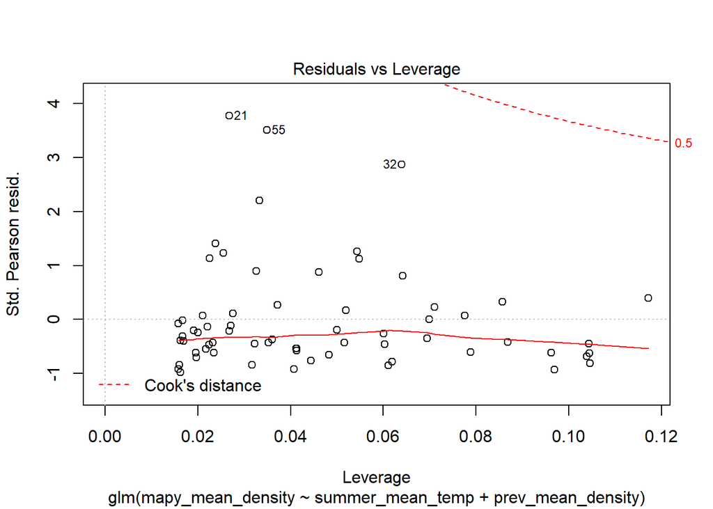

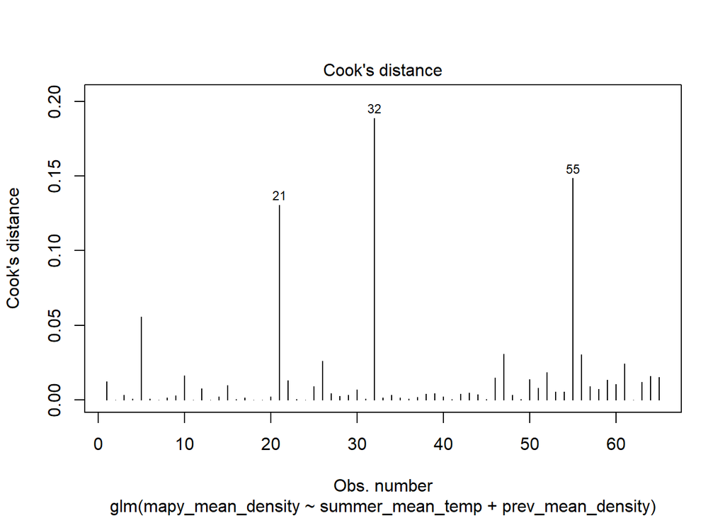

The residuals skew right.

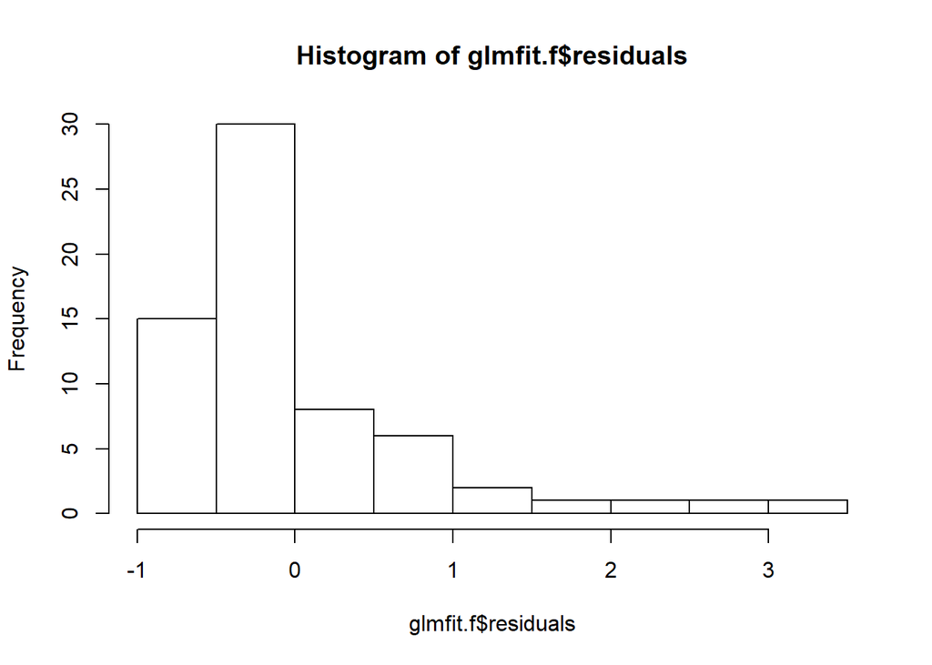

#### Model Selection: AIC

Backward Selection

```
## Start:  AIC=-30.31
## mapy_mean_density ~ site + urchin_presence + urchin_abundance +
##     mean_ammonia + mean_no2_no3 + mean_po4 + mean_tchl + mean_pon +
##     summer_mean_temp + summer_var_temp + prev_mean_density +
##     site:prev_mean_density
##
##
## Step:  AIC=-30.31
## mapy_mean_density ~ site + urchin_abundance + mean_ammonia +
##     mean_no2_no3 + mean_po4 + mean_tchl + mean_pon + summer_mean_temp +
##     summer_var_temp + prev_mean_density + site:prev_mean_density
##
##                          Df Deviance     AIC
## - site:prev_mean_density  4   21.209 -37.303
## - summer_var_temp         1   20.687 -32.282
## - mean_pon                1   20.716 -32.227
## - mean_po4                1   20.784 -32.100
## - mean_ammonia            1   20.860 -31.958
## - mean_tchl               1   21.344 -31.050
## - mean_no2_no3            1   21.566 -30.633
## <none>                        20.672 -30.310
## - summer_mean_temp        1   22.431 -29.012
## - urchin_abundance        1   23.458 -27.086
##
## Step:  AIC=-36.55
## mapy_mean_density ~ site + urchin_abundance + mean_ammonia +
##     mean_no2_no3 + mean_po4 + mean_tchl + mean_pon + summer_mean_temp +
##     summer_var_temp + prev_mean_density
##
##                     Df Deviance     AIC
## - summer_var_temp    1   21.214 -38.544
## - mean_pon           1   21.276 -38.423
## - mean_po4           1   21.483 -38.013
## - mean_ammonia       1   21.702 -37.578
## - mean_tchl          1   21.800 -37.384
## - mean_no2_no3       1   22.139 -36.714
## <none>                   21.209 -36.555
## - prev_mean_density  1   22.426 -36.144
## - summer_mean_temp   1   23.088 -34.833
## - site               4   26.856 -33.371
```

[output cut: 50 more lines]

```
## mapy_mean_density ~ site + urchin_abundance + mean_no2_no3 +
##     mean_tchl + summer_mean_temp + prev_mean_density
##
##                     Df Deviance     AIC
## - mean_tchl          1   22.570 -42.982
## - mean_no2_no3       1   22.803 -42.503
## <none>                   21.898 -42.364
## - prev_mean_density  1   23.727 -40.603
## - summer_mean_temp   1   24.381 -39.259
## - urchin_abundance   1   25.885 -36.166
## - site               4   29.199 -35.353
##
## Step:  AIC=-42.29
## mapy_mean_density ~ site + urchin_abundance + mean_no2_no3 +
##     summer_mean_temp + prev_mean_density
```

Forward Selection

```
## Start:  AIC=7.51
## mapy_mean_density ~ 1
##
##                     Df Deviance     AIC
## + prev_mean_density  1   38.723 -4.7237
## + urchin_presence    1   44.305 -0.3830
## + summer_mean_temp   1   47.070  1.7671
## + site               4   41.417  3.3706
## + mean_no2_no3       1   53.657  6.8891
## <none>                   57.024  7.5069
## + summer_var_temp    1   56.603  9.1795
## + mean_pon           1   56.897  9.4086
## + mean_po4           1   56.911  9.4191
## + urchin_abundance   1   56.982  9.4748
## + mean_ammonia       1   57.005  9.4926
## + mean_tchl          1   57.009  9.4953
##
## Step:  AIC=-18.56
## mapy_mean_density ~ prev_mean_density
##
##                    Df Deviance     AIC
## + summer_mean_temp  1   31.292 -24.846
## + urchin_presence   1   36.077 -19.512
## <none>                  38.723 -18.562
## + mean_ammonia      1   37.057 -18.421
## + mean_no2_no3      1   37.152 -18.314
## + mean_po4          1   37.443 -17.989
## + mean_tchl         1   37.966 -17.407
## + summer_var_temp   1   38.201 -17.145
## + mean_pon          1   38.263 -17.076
## + urchin_abundance  1   38.721 -16.565
## + site              4   33.925 -15.911
##
## Step:  AIC=-31.62
## mapy_mean_density ~ prev_mean_density + summer_mean_temp
##
##                    Df Deviance     AIC
## + urchin_presence   1   28.573 -33.614
## <none>                  31.293 -31.618
## + mean_no2_no3      1   30.145 -31.305
## + summer_var_temp   1   30.684 -30.513
## + mean_tchl         1   30.823 -30.309
## + urchin_abundance  1   30.936 -30.141
## + mean_pon          1   31.098 -29.904
## + mean_ammonia      1   31.122 -29.868
## + mean_po4          1   31.243 -29.691
## + site              4   27.518 -29.165
##
## Step:  AIC=-35.97
## mapy_mean_density ~ prev_mean_density + summer_mean_temp + urchin_presence
##
##                    Df Deviance     AIC
## <none>                  28.573 -35.972
## + mean_no2_no3      1   27.439 -35.783
## + urchin_abundance  1   28.003 -34.882
## + summer_var_temp   1   28.222 -34.533
## + mean_ammonia      1   28.295 -34.416
## + mean_tchl         1   28.433 -34.196
## + mean_pon          1   28.514 -34.067
## + mean_po4          1   28.573 -33.973
## + site              3   27.518 -31.657
```

Forward and backward selection chose different models. Compare their fits

```
##
## Call:
## glm(formula = mapy_mean_density ~ prev_mean_density + summer_mean_temp +
##     urchin_presence, family = Gamma(link = "log"), data = abund_dat)
##
## Deviance Residuals:
##      Min        1Q    Median        3Q       Max
## -1.23694  -0.50399  -0.29744   0.02675   1.82883
##
## Coefficients:
##                   Estimate Std. Error t value Pr(>|t|)
## (Intercept)        -6.7376     1.7032  -3.956 0.000201 ***
## prev_mean_density   0.4137     0.1183   3.498 0.000880 ***
## summer_mean_temp    0.3485     0.1030   3.384 0.001255 **
## urchin_presence1    0.6467     0.2824   2.290 0.025467 *
## ---
## Signif. codes:  0 '***' 0.001 '**' 0.01 '*' 0.05 '.' 0.1 ' ' 1
##
## (Dispersion parameter for Gamma family taken to be 0.6259687)
##
##     Null deviance: 57.024  on 64  degrees of freedom
## Residual deviance: 28.573  on 61  degrees of freedom
## AIC: -35.972
##
## Number of Fisher Scoring iterations: 5
```

```
##
## Call:
## glm(formula = mapy_mean_density ~ site + urchin_abundance + mean_no2_no3 +
##     summer_mean_temp + prev_mean_density, family = Gamma(link = "log"),
##     data = abund_dat)
##
## Deviance Residuals:
##     Min       1Q   Median       3Q      Max
## -1.2094  -0.4601  -0.1621   0.1400   1.5136
##
## Coefficients:
##                     Estimate Std. Error t value Pr(>|t|)
## (Intercept)       -5.1053078  1.7611153  -2.899 0.005338 **
## siteAQUE           0.6215488  0.4057995   1.532 0.131235
## siteCARP           2.2431656  0.6580998   3.409 0.001217 **
## siteMOHK           1.8476791  0.4925503   3.751 0.000419 ***
## siteNAPL           1.6025380  0.4858903   3.298 0.001695 **
## urchin_abundance  -0.1234745  0.0445117  -2.774 0.007510 **
## mean_no2_no3       0.0005850  0.0004915   1.190 0.238963
## summer_mean_temp   0.1953996  0.1037623   1.883 0.064878 .
## prev_mean_density  0.2563472  0.1185209   2.163 0.034835 *
## ---
## Signif. codes:  0 '***' 0.001 '**' 0.01 '*' 0.05 '.' 0.1 ' ' 1
##
## (Dispersion parameter for Gamma family taken to be 0.4892106)
##
##     Null deviance: 57.024  on 64  degrees of freedom
## Residual deviance: 22.570  on 56  degrees of freedom
## AIC: -42.289
##
## Number of Fisher Scoring iterations: 10
```

What does the ANOVA say?

```
## Analysis of Deviance Table
##
## Model 1: mapy_mean_density ~ prev_mean_density + summer_mean_temp + urchin_presence
## Model 2: mapy_mean_density ~ site + urchin_abundance + mean_no2_no3 +
##     summer_mean_temp + prev_mean_density
##   Resid. Df Resid. Dev Df Deviance      F  Pr(>F)
## 1        61     28.573
## 2        56     22.570  5   6.0035 2.4543 0.04425 *
## ---
## Signif. codes:  0 '***' 0.001 '**' 0.01 '*' 0.05 '.' 0.1 ' ' 1
```

## Kelp Size

*Response:* log(`mapy_mean_fronds`)

Since there are some missing data in the kelp size categories, I’m going to select only the variables we are interested in at the moment and filter for missing data.

```
##  [1] "mapy_mean_fronds" "site"             "urchin_presence"  "urchin_abundance"
##  [5] "prev_mean_fronds" "mean_ammonia"     "mean_no2_no3"     "mean_po4"
##  [9] "mean_tchl"        "mean_pon"         "summer_mean_temp" "summer_var_temp"
```

### LM

Model Type: OLS, Log transformation of response

#### Model Selection: BIC

Backward model selection

```
## Start:  AIC=18.54
## log(mapy_mean_fronds) ~ site + urchin_presence + urchin_abundance +
##     prev_mean_fronds + site:prev_mean_fronds + mean_ammonia +
##     mean_no2_no3 + mean_po4 + mean_tchl + mean_pon + summer_mean_temp +
##     summer_var_temp
##
##
## Step:  AIC=18.54
## log(mapy_mean_fronds) ~ site + urchin_abundance + prev_mean_fronds +
##     mean_ammonia + mean_no2_no3 + mean_po4 + mean_tchl + mean_pon +
##     summer_mean_temp + summer_var_temp + site:prev_mean_fronds
##
##                         Df Sum of Sq    RSS     AIC
## - site:prev_mean_fronds  4   2.46009 29.670  7.4646
## - mean_tchl              1   0.00782 27.218 14.3803
## - summer_var_temp        1   0.01005 27.220 14.3856
## - mean_pon               1   0.02762 27.237 14.4275
## - urchin_abundance       1   0.44599 27.656 15.4183
## - summer_mean_temp       1   0.74781 27.957 16.1239
## - mean_po4               1   1.79625 29.006 18.5169
## <none>                               27.210 18.5360
## - mean_ammonia           1   1.84644 29.056 18.6293
## - mean_no2_no3           1   2.79214 30.002 20.7111
##
## Step:  AIC=7.46
## log(mapy_mean_fronds) ~ site + urchin_abundance + prev_mean_fronds +
##     mean_ammonia + mean_no2_no3 + mean_po4 + mean_tchl + mean_pon +
##     summer_mean_temp + summer_var_temp
##
##                    Df Sum of Sq    RSS    AIC
## - mean_pon          1    0.0026 29.672 3.2960
## - mean_tchl         1    0.0099 29.680 3.3119
## - summer_var_temp   1    0.0701 29.740 3.4435
## - prev_mean_fronds  1    0.3313 30.001 4.0119
## - summer_mean_temp  1    0.5868 30.257 4.5633
## - urchin_abundance  1    0.6259 30.296 4.6471
## - mean_po4          1    1.3958 31.066 6.2784
## <none>                          29.670 7.4646
## - mean_no2_no3      1    1.9912 31.661 7.5123
## - mean_ammonia      1    2.2279 31.898 7.9964
```

[output cut: 93 more lines]

```
##
## Step:  AIC=-16.37
## log(mapy_mean_fronds) ~ site + mean_ammonia
##
##                Df Sum of Sq    RSS     AIC
## - mean_ammonia  1    0.9602 35.332 -18.752
## <none>                      34.372 -16.369
## - site          4   11.5905 45.962 -14.178
##
## Step:  AIC=-18.75
## log(mapy_mean_fronds) ~ site
##
##        Df Sum of Sq    RSS     AIC
## <none>              35.332 -18.752
## - site  4    11.555 46.887 -17.058
```

Forward Model Selection

```
## Start:  AIC=-17.06
## log(mapy_mean_fronds) ~ 1
##
##                    Df Sum of Sq    RSS     AIC
## + site              4   11.5551 35.332 -18.752
## <none>                          46.887 -17.058
## + prev_mean_fronds  1    2.0175 44.870 -15.742
## + mean_no2_no3      1    1.7075 45.180 -15.294
## + urchin_presence   1    1.5292 45.358 -15.038
## + urchin_abundance  1    1.0519 45.835 -14.358
## + mean_ammonia      1    0.9248 45.962 -14.178
## + summer_var_temp   1    0.8422 46.045 -14.061
## + summer_mean_temp  1    0.4395 46.448 -13.495
## + mean_pon          1    0.2157 46.671 -13.183
## + mean_tchl         1    0.0649 46.822 -12.973
## + mean_po4          1    0.0303 46.857 -12.925
##
## Step:  AIC=-18.75
## log(mapy_mean_fronds) ~ site
##
##                    Df Sum of Sq    RSS     AIC
## <none>                          35.332 -18.752
## + mean_ammonia      1   0.96021 34.372 -16.369
## + mean_no2_no3      1   0.82875 34.503 -16.120
## + urchin_abundance  1   0.40866 34.923 -15.334
## + mean_po4          1   0.30689 35.025 -15.145
## + mean_pon          1   0.30431 35.028 -15.140
## + summer_var_temp   1   0.19474 35.137 -14.937
## + summer_mean_temp  1   0.15249 35.179 -14.859
## + prev_mean_fronds  1   0.03696 35.295 -14.646
## + mean_tchl         1   0.02740 35.305 -14.628
```

Forward and backward selection produces the same model! Check out the fit

```
##
## Call:
## lm(formula = log(mapy_mean_fronds) ~ site, data = size_dat)
##
## Residuals:
##     Min      1Q  Median      3Q     Max
## -1.6629 -0.4184  0.0121  0.4401  2.0030
##
## Coefficients:
##             Estimate Std. Error t value Pr(>|t|)
## (Intercept)  1.98136    0.21283   9.310 2.99e-13 ***
## siteAQUE     1.22128    0.40382   3.024  0.00366 **
## siteCARP     0.04062    0.28653   0.142  0.88774
## siteMOHK     0.87764    0.30099   2.916  0.00498 **
## siteNAPL     0.09858    0.27931   0.353  0.72538
## ---
## Signif. codes:  0 '***' 0.001 '**' 0.01 '*' 0.05 '.' 0.1 ' ' 1
##
## Residual standard error: 0.7674 on 60 degrees of freedom
## Multiple R-squared:  0.2464, Adjusted R-squared:  0.1962
## F-statistic: 4.906 on 4 and 60 DF,  p-value: 0.001727
```

Yeah so… it’s a pretty terrible model.

#### Model Selection: AIC

Backward model selection

```
## Start:  AIC=-20.6
## log(mapy_mean_fronds) ~ site + urchin_presence + urchin_abundance +
##     prev_mean_fronds + site:prev_mean_fronds + mean_ammonia +
##     mean_no2_no3 + mean_po4 + mean_tchl + mean_pon + summer_mean_temp +
##     summer_var_temp
##
##
## Step:  AIC=-20.6
## log(mapy_mean_fronds) ~ site + urchin_abundance + prev_mean_fronds +
##     mean_ammonia + mean_no2_no3 + mean_po4 + mean_tchl + mean_pon +
##     summer_mean_temp + summer_var_temp + site:prev_mean_fronds
##
##                         Df Sum of Sq    RSS     AIC
## - site:prev_mean_fronds  4   2.46009 29.670 -22.977
## - mean_tchl              1   0.00782 27.218 -22.584
## - summer_var_temp        1   0.01005 27.220 -22.579
## - mean_pon               1   0.02762 27.237 -22.537
## - urchin_abundance       1   0.44599 27.656 -21.546
## - summer_mean_temp       1   0.74781 27.957 -20.841
## <none>                               27.210 -20.603
## - mean_po4               1   1.79625 29.006 -18.448
## - mean_ammonia           1   1.84644 29.056 -18.335
## - mean_no2_no3           1   2.79214 30.002 -16.253
##
## Step:  AIC=-22.98
## log(mapy_mean_fronds) ~ site + urchin_abundance + prev_mean_fronds +
##     mean_ammonia + mean_no2_no3 + mean_po4 + mean_tchl + mean_pon +
##     summer_mean_temp + summer_var_temp
##
##                    Df Sum of Sq    RSS     AIC
## - mean_pon          1    0.0026 29.672 -24.971
## - mean_tchl         1    0.0099 29.680 -24.955
## - summer_var_temp   1    0.0701 29.740 -24.823
## - prev_mean_fronds  1    0.3313 30.001 -24.255
## - summer_mean_temp  1    0.5868 30.257 -23.704
## - urchin_abundance  1    0.6259 30.296 -23.620
## <none>                          29.670 -22.977
## - mean_po4          1    1.3958 31.066 -21.989
## - mean_no2_no3      1    1.9912 31.661 -20.755
## - mean_ammonia      1    2.2279 31.898 -20.271
```

[output cut: 58 more lines]

```
## - mean_no2_no3      1    2.0132 32.159 -27.741
## - mean_ammonia      1    2.1508 32.296 -27.463
## - site              4   10.4735 40.619 -18.560
##
## Step:  AIC=-30.6
## log(mapy_mean_fronds) ~ site + mean_ammonia + mean_no2_no3 +
##     mean_po4 + summer_mean_temp
##
##                    Df Sum of Sq    RSS     AIC
## <none>                          30.773 -30.604
## - mean_po4          1    0.9883 31.761 -30.549
## - mean_no2_no3      1    1.8215 32.595 -28.866
## - summer_mean_temp  1    1.9502 32.723 -28.610
## - mean_ammonia      1    2.2148 32.988 -28.086
## - site              4   11.7321 42.505 -17.610
```

Forward Model Selection

```
## Start:  AIC=-19.23
## log(mapy_mean_fronds) ~ 1
##
##                    Df Sum of Sq    RSS     AIC
## + site              4   11.5551 35.332 -29.624
## + prev_mean_fronds  1    2.0175 44.870 -20.091
## + mean_no2_no3      1    1.7075 45.180 -19.643
## + urchin_presence   1    1.5292 45.358 -19.387
## <none>                          46.887 -19.232
## + urchin_abundance  1    1.0519 45.835 -18.707
## + mean_ammonia      1    0.9248 45.962 -18.527
## + summer_var_temp   1    0.8422 46.045 -18.410
## + summer_mean_temp  1    0.4395 46.448 -17.844
## + mean_pon          1    0.2157 46.671 -17.532
## + mean_tchl         1    0.0649 46.822 -17.322
## + mean_po4          1    0.0303 46.857 -17.274
##
## Step:  AIC=-29.62
## log(mapy_mean_fronds) ~ site
##
##                    Df Sum of Sq    RSS     AIC
## <none>                          35.332 -29.624
## + mean_ammonia      1   0.96021 34.372 -29.415
## + mean_no2_no3      1   0.82875 34.503 -29.167
## + urchin_abundance  1   0.40866 34.923 -28.380
## + mean_po4          1   0.30689 35.025 -28.191
## + mean_pon          1   0.30431 35.028 -28.186
## + summer_var_temp   1   0.19474 35.137 -27.983
## + summer_mean_temp  1   0.15249 35.179 -27.905
## + prev_mean_fronds  1   0.03696 35.295 -27.692
## + mean_tchl         1   0.02740 35.305 -27.674
```

Forward and backward selection produces very different models. Since we already saw the model with just site as a predictor variable, Let’s look at the larger model.

```
##
## Call:
## lm(formula = log(mapy_mean_fronds) ~ site + mean_ammonia + mean_no2_no3 +
##     mean_po4 + summer_mean_temp, data = size_dat)
##
## Residuals:
##      Min       1Q   Median       3Q      Max
## -1.54868 -0.46565 -0.01502  0.37898  1.75861
##
## Coefficients:
##                    Estimate Std. Error t value Pr(>|t|)
## (Intercept)      -2.3378364  2.3743359  -0.985  0.32904
## siteAQUE          1.0626657  0.3956042   2.686  0.00949 **
## siteCARP         -0.3227097  0.3147033  -1.025  0.30956
## siteMOHK          0.7446062  0.3038311   2.451  0.01741 *
## siteNAPL          0.2869888  0.2806249   1.023  0.31086
## mean_ammonia      0.0008523  0.0004245   2.008  0.04952 *
## mean_no2_no3     -0.0009991  0.0005488  -1.821  0.07401 .
## mean_po4          0.0006398  0.0004771   1.341  0.18532
## summer_mean_temp  0.2439895  0.1295173   1.884  0.06478 .
## ---
## Signif. codes:  0 '***' 0.001 '**' 0.01 '*' 0.05 '.' 0.1 ' ' 1
##
## Residual standard error: 0.7413 on 56 degrees of freedom
## Multiple R-squared:  0.3437, Adjusted R-squared:  0.2499
## F-statistic: 3.665 on 8 and 56 DF,  p-value: 0.001692
```

Still a pretty terrible model.

### GLM

Model Type: GLM, `family=Gamma(link='log')`

#### Model Selection: BIC

Backward Selection

```
## Start:  AIC=503.18
## mapy_mean_fronds ~ site + urchin_presence + urchin_abundance +
##     mean_ammonia + mean_no2_no3 + mean_po4 + mean_tchl + mean_pon +
##     summer_mean_temp + summer_var_temp + prev_mean_fronds + site:prev_mean_fronds
##
##
## Step:  AIC=503.18
## mapy_mean_fronds ~ site + urchin_abundance + mean_ammonia + mean_no2_no3 +
##     mean_po4 + mean_tchl + mean_pon + summer_mean_temp + summer_var_temp +
##     prev_mean_fronds + site:prev_mean_fronds
##
##                         Df Deviance    AIC
## - site:prev_mean_fronds  4   27.828 490.71
## - mean_tchl              1   25.775 499.03
## - mean_pon               1   25.808 499.10
## - summer_var_temp        1   25.821 499.12
## - urchin_abundance       1   26.230 499.96
## - summer_mean_temp       1   26.486 500.49
## - mean_po4               1   27.123 501.79
## - mean_ammonia           1   27.597 502.76
## <none>                       25.766 503.18
## - mean_no2_no3           1   28.072 503.74
##
## Step:  AIC=491.83
## mapy_mean_fronds ~ site + urchin_abundance + mean_ammonia + mean_no2_no3 +
##     mean_po4 + mean_tchl + mean_pon + summer_mean_temp + summer_var_temp +
##     prev_mean_fronds
##
##                    Df Deviance    AIC
## - site              4   33.397 486.89
## - mean_tchl         1   27.828 487.66
## - prev_mean_fronds  1   27.829 487.66
## - mean_pon          1   27.852 487.71
## - summer_var_temp   1   27.926 487.86
## - summer_mean_temp  1   28.446 488.96
## - urchin_abundance  1   28.493 489.06
## - mean_po4          1   28.839 489.79
## - mean_no2_no3      1   29.367 490.90
## - mean_ammonia      1   29.744 491.70
## <none>                  27.828 491.83
```

[output cut: 84 more lines]

```
## mapy_mean_fronds ~ urchin_abundance + mean_ammonia + mean_no2_no3
##
##                    Df Deviance    AIC
## - mean_ammonia      1   36.954 466.12
## <none>                  35.431 467.03
## - mean_no2_no3      1   38.174 468.73
## - urchin_abundance  1   40.046 472.74
##
## Step:  AIC=465.83
## mapy_mean_fronds ~ urchin_abundance + mean_no2_no3
##
##                    Df Deviance    AIC
## <none>                  36.954 465.83
## - mean_no2_no3      1   39.346 466.71
## - urchin_abundance  1   40.727 469.63
```

Forward Selection

```
## Start:  AIC=470.71
## mapy_mean_fronds ~ 1
##
##                    Df Deviance    AIC
## + urchin_abundance  1   39.346 467.80
## + mean_no2_no3      1   40.727 469.71
## <none>                  44.457 470.71
## + site              4   32.802 471.26
## + prev_mean_fronds  1   42.138 471.67
## + mean_ammonia      1   44.147 474.45
## + mean_tchl         1   44.203 474.53
## + urchin_presence   1   44.315 474.69
## + summer_mean_temp  1   44.403 474.81
## + mean_pon          1   44.410 474.82
## + summer_var_temp   1   44.418 474.83
## + mean_po4          1   44.447 474.87
##
## Step:  AIC=466.12
## mapy_mean_fronds ~ urchin_abundance
##
##                    Df Deviance    AIC
## + mean_no2_no3      1   36.954 465.92
## <none>                  39.346 466.12
## + prev_mean_fronds  1   37.517 466.95
## + urchin_presence   1   37.675 467.24
## + mean_ammonia      1   38.174 468.15
## + mean_po4          1   39.095 469.84
## + site              4   32.333 469.99
## + mean_tchl         1   39.274 470.17
## + summer_var_temp   1   39.286 470.19
## + summer_mean_temp  1   39.308 470.23
## + mean_pon          1   39.344 470.29
##
## Step:  AIC=465.83
## mapy_mean_fronds ~ urchin_abundance + mean_no2_no3
##
##                    Df Deviance    AIC
## <none>                  36.954 465.83
## + urchin_presence   1   35.380 466.68
## + mean_ammonia      1   35.431 466.79
## + prev_mean_fronds  1   36.082 468.17
## + mean_po4          1   36.154 468.32
## + summer_var_temp   1   36.937 469.97
## + mean_tchl         1   36.939 469.98
## + mean_pon          1   36.940 469.98
## + summer_mean_temp  1   36.952 470.00
## + site              4   31.213 470.41
```

Forward and backward selection chose the same model; very different from the OLS model.

```
##
## Call:
## glm(formula = mapy_mean_fronds ~ urchin_abundance + mean_no2_no3,
##     family = Gamma(link = "log"), data = size_dat)
##
## Deviance Residuals:
##     Min       1Q   Median       3Q      Max
## -1.9290  -0.7092  -0.1379   0.3105   1.3239
##
## Coefficients:
##                    Estimate Std. Error t value Pr(>|t|)
## (Intercept)       3.7785994  0.3726935  10.139 8.74e-15 ***
## urchin_abundance -0.0548602  0.0180318  -3.042  0.00344 **
## mean_no2_no3     -0.0010800  0.0004543  -2.378  0.02052 *
## ---
## Signif. codes:  0 '***' 0.001 '**' 0.01 '*' 0.05 '.' 0.1 ' ' 1
##
## (Dispersion parameter for Gamma family taken to be 0.4735908)
##
##     Null deviance: 44.457  on 64  degrees of freedom
## Residual deviance: 36.954  on 62  degrees of freedom
## AIC: 459.31
##
## Number of Fisher Scoring iterations: 6
```

```
## Analysis of Deviance Table
##
## Model 1: mapy_mean_fronds ~ 1
## Model 2: mapy_mean_fronds ~ urchin_abundance + mean_no2_no3
##   Resid. Df Resid. Dev Df Deviance      F    Pr(>F)
## 1        64     44.457
## 2        62     36.954  2   7.5025 7.9209 0.0008641 ***
## ---
## Signif. codes:  0 '***' 0.001 '**' 0.01 '*' 0.05 '.' 0.1 ' ' 1
```

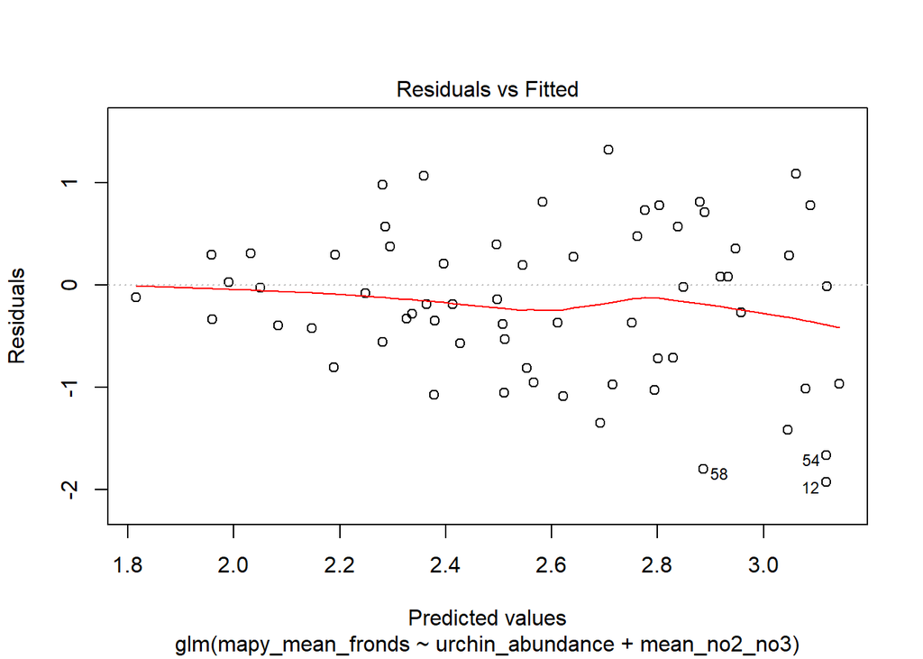

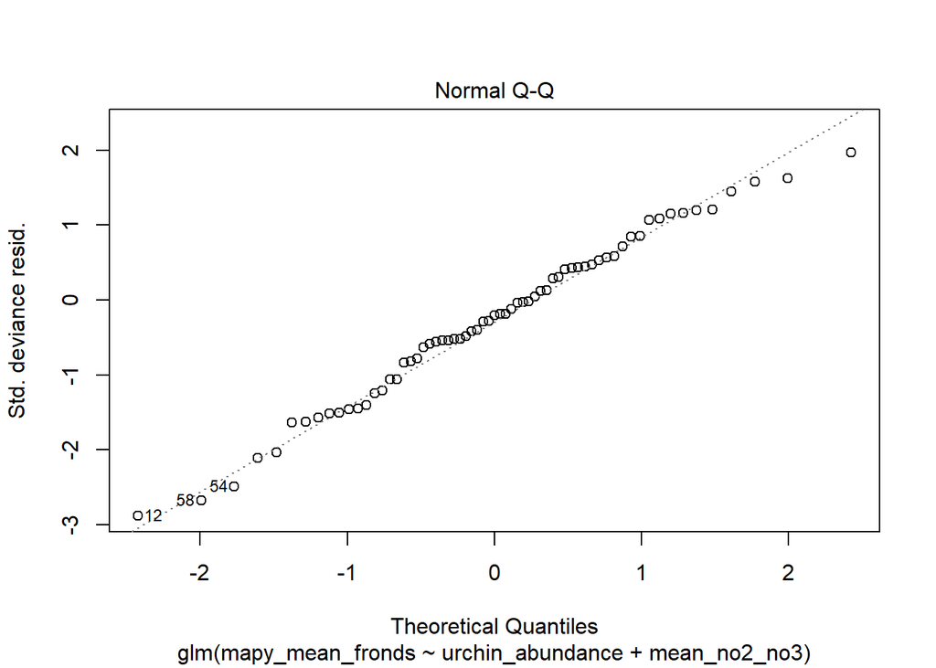

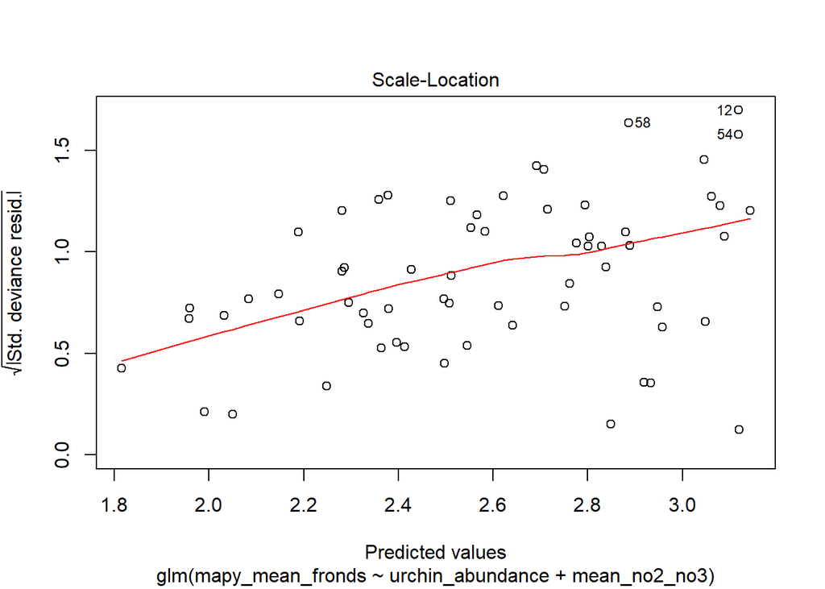

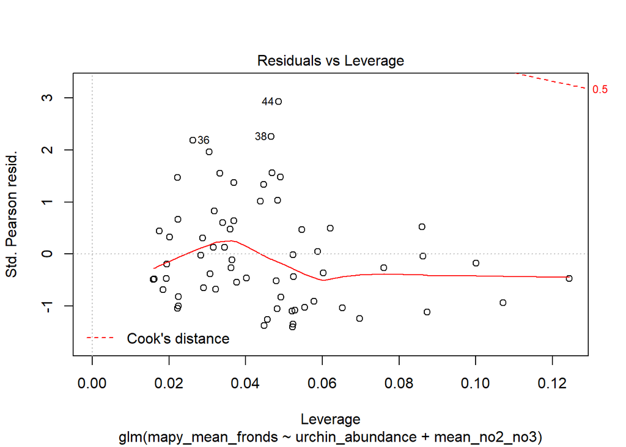

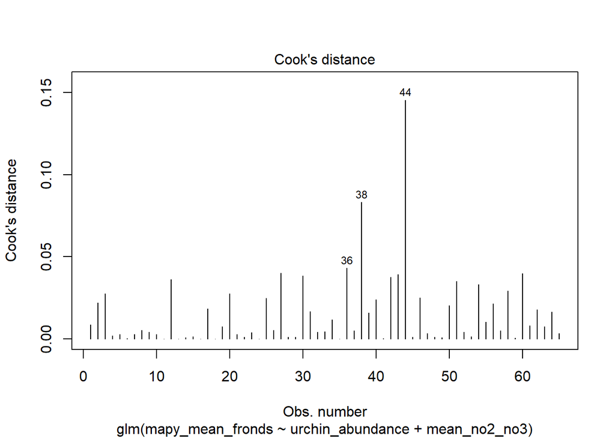

There is non-constant variance of residuals according to the TA plot.

#### Model Selection: AIC

Backward Selection

```
## Start:  AIC=464.05
## mapy_mean_fronds ~ site + urchin_presence + urchin_abundance +
##     mean_ammonia + mean_no2_no3 + mean_po4 + mean_tchl + mean_pon +
##     summer_mean_temp + summer_var_temp + prev_mean_fronds + site:prev_mean_fronds
##
##
## Step:  AIC=464.05
## mapy_mean_fronds ~ site + urchin_abundance + mean_ammonia + mean_no2_no3 +
##     mean_po4 + mean_tchl + mean_pon + summer_mean_temp + summer_var_temp +
##     prev_mean_fronds + site:prev_mean_fronds
##
##                         Df Deviance    AIC
## - site:prev_mean_fronds  4   27.828 460.27
## - mean_tchl              1   25.775 462.06
## - mean_pon               1   25.808 462.13
## - summer_var_temp        1   25.821 462.16
## - urchin_abundance       1   26.230 463.00
## - summer_mean_temp       1   26.486 463.52
## <none>                       25.766 464.05
## - mean_po4               1   27.123 464.83
## - mean_ammonia           1   27.597 465.80
## - mean_no2_no3           1   28.072 466.77
##
## Step:  AIC=461.39
## mapy_mean_fronds ~ site + urchin_abundance + mean_ammonia + mean_no2_no3 +
##     mean_po4 + mean_tchl + mean_pon + summer_mean_temp + summer_var_temp +
##     prev_mean_fronds
##
##                    Df Deviance    AIC
## - mean_tchl         1   27.828 459.39
## - prev_mean_fronds  1   27.829 459.39
## - mean_pon          1   27.852 459.44
## - summer_var_temp   1   27.926 459.59
## - summer_mean_temp  1   28.446 460.69
## - urchin_abundance  1   28.493 460.79
## <none>                  27.828 461.39
## - mean_po4          1   28.839 461.52
## - mean_no2_no3      1   29.367 462.64
## - mean_ammonia      1   29.744 463.43
## - site              4   33.397 465.15
```

[output cut: 75 more lines]

```
##                    Df Deviance    AIC
## - urchin_abundance  1   30.139 452.93
## <none>                  29.305 452.99
## - mean_no2_no3      1   30.703 454.25
## - mean_ammonia      1   31.213 455.43
## - site              4   35.431 459.26
##
## Step:  AIC=452.95
## mapy_mean_fronds ~ site + mean_ammonia + mean_no2_no3
##
##                Df Deviance    AIC
## <none>              30.139 452.95
## - mean_ammonia  1   31.561 454.22
## - mean_no2_no3  1   31.653 454.43
## - site          4   40.046 467.72
```

Forward Selection

```
## Start:  AIC=468.53
## mapy_mean_fronds ~ 1
##
##                    Df Deviance    AIC
## + site              4   32.802 460.38
## + urchin_abundance  1   39.346 463.45
## + mean_no2_no3      1   40.727 465.37
## + prev_mean_fronds  1   42.138 467.32
## <none>                  44.457 468.53
## + mean_ammonia      1   44.147 470.10
## + mean_tchl         1   44.203 470.18
## + urchin_presence   1   44.315 470.34
## + summer_mean_temp  1   44.403 470.46
## + mean_pon          1   44.410 470.47
## + summer_var_temp   1   44.418 470.48
## + mean_po4          1   44.447 470.52
##
## Step:  AIC=454.89
## mapy_mean_fronds ~ site
##
##                    Df Deviance    AIC
## + mean_no2_no3      1   31.561 454.32
## + mean_ammonia      1   31.653 454.51
## <none>                  32.802 454.89
## + urchin_abundance  1   32.333 455.92
## + mean_po4          1   32.703 456.69
## + summer_var_temp   1   32.705 456.69
## + prev_mean_fronds  1   32.730 456.74
## + mean_pon          1   32.751 456.78
## + mean_tchl         1   32.769 456.82
## + summer_mean_temp  1   32.794 456.87
##
## Step:  AIC=454.18
## mapy_mean_fronds ~ site + mean_no2_no3
##
##                    Df Deviance    AIC
## + mean_ammonia      1   30.139 453.04
## <none>                  31.561 454.18
## + mean_po4          1   31.015 454.98
## + urchin_abundance  1   31.213 455.41
## + summer_var_temp   1   31.503 456.05
## + mean_pon          1   31.538 456.13
## + mean_tchl         1   31.553 456.16
## + prev_mean_fronds  1   31.558 456.17
## + summer_mean_temp  1   31.561 456.18
##
## Step:  AIC=452.95
## mapy_mean_fronds ~ site + mean_no2_no3 + mean_ammonia
##
##                    Df Deviance    AIC
## <none>                  30.139 452.95
## + urchin_abundance  1   29.305 453.04
## + summer_mean_temp  1   29.417 453.29
## + mean_po4          1   29.982 454.59
## + summer_var_temp   1   30.073 454.80
## + mean_tchl         1   30.106 454.88
## + mean_pon          1   30.133 454.94
## + prev_mean_fronds  1   30.139 454.95
```

```
##
## Call:
## glm(formula = mapy_mean_fronds ~ site + mean_no2_no3 + mean_ammonia,
##     family = Gamma(link = "log"), data = size_dat)
##
## Deviance Residuals:
##     Min       1Q   Median       3Q      Max
## -1.7120  -0.5544  -0.1201   0.3141   1.4169
##
## Coefficients:
##                Estimate Std. Error t value Pr(>|t|)
## (Intercept)   2.9137987  0.4134515   7.047 2.44e-09 ***
## siteAQUE      0.4510609  0.3514420   1.283   0.2044
## siteCARP     -0.6434631  0.2546737  -2.527   0.0143 *
## siteMOHK      0.3870202  0.2589478   1.495   0.1404
## siteNAPL     -0.3772972  0.2479055  -1.522   0.1335
## mean_no2_no3 -0.0008626  0.0004590  -1.879   0.0652 .
## mean_ammonia  0.0005747  0.0003053   1.883   0.0648 .
## ---
## Signif. codes:  0 '***' 0.001 '**' 0.01 '*' 0.05 '.' 0.1 ' ' 1
##
## (Dispersion parameter for Gamma family taken to be 0.4351946)
##
##     Null deviance: 44.457  on 64  degrees of freedom
## Residual deviance: 30.139  on 58  degrees of freedom
## AIC: 452.95
##
## Number of Fisher Scoring iterations: 7
```

```
## Analysis of Deviance Table
##
## Model 1: mapy_mean_fronds ~ 1
## Model 2: mapy_mean_fronds ~ site + mean_no2_no3 + mean_ammonia
##   Resid. Df Resid. Dev Df Deviance      F    Pr(>F)
## 1        64     44.457
## 2        58     30.139  6   14.318 5.4832 0.0001502 ***
## ---
## Signif. codes:  0 '***' 0.001 '**' 0.01 '*' 0.05 '.' 0.1 ' ' 1
```

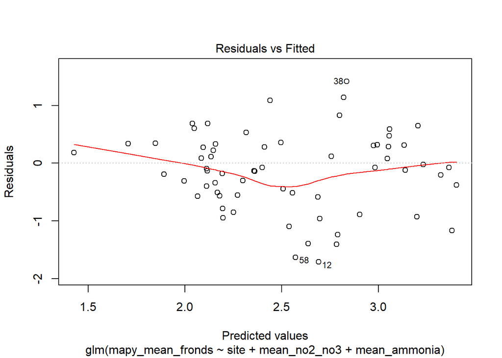

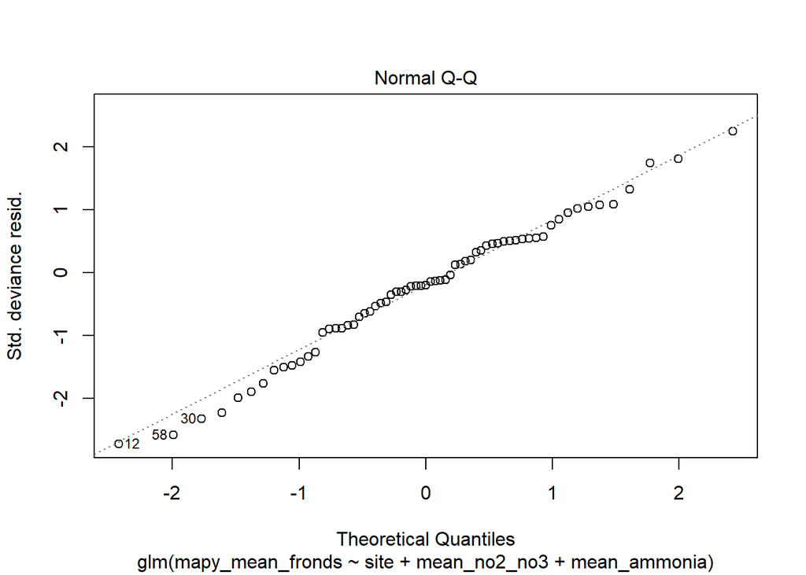

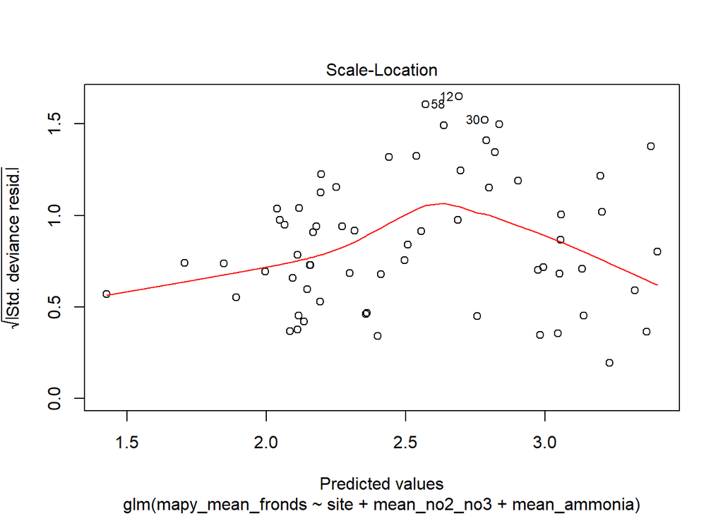

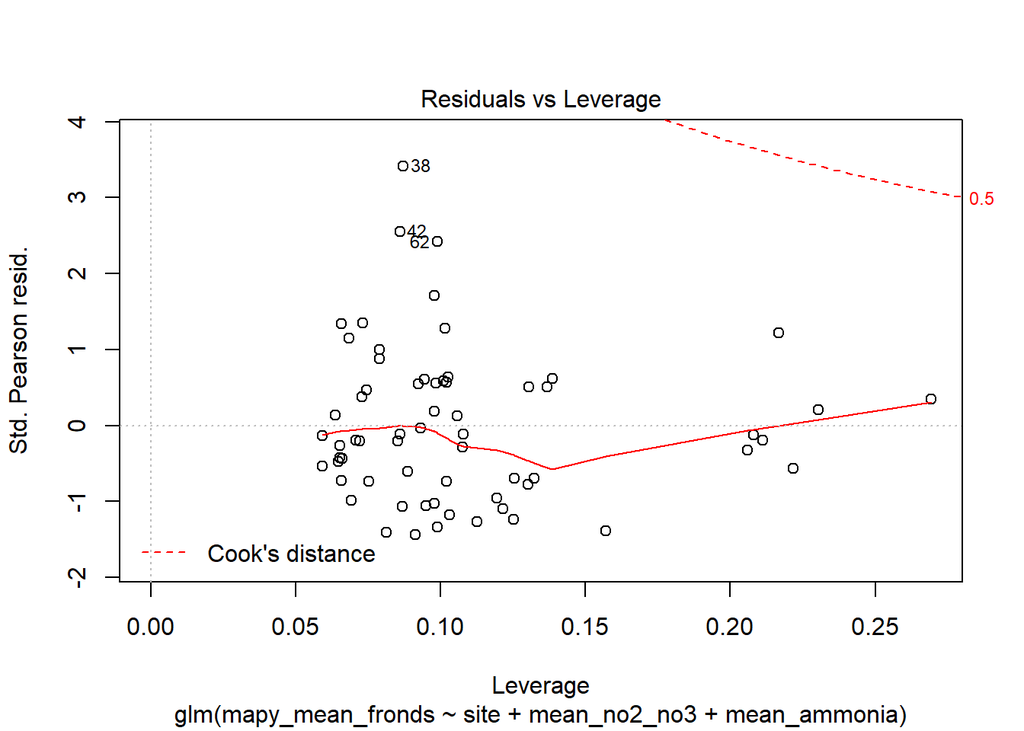

Maybe some non-constant variance, but overall it seems ok.

## Kelp Size (holdfasts)

*Response:* `mapy_mean_hld`

Interactions: site by previous mean size

Since there are some missing data in the kelp size categories, I’m going to select only the variables we are interested in at the moment and filter for no missing data.

```
##  [1] "mapy_mean_hld"    "site"             "urchin_presence"  "urchin_abundance"
##  [5] "prev_mean_hld"    "mean_ammonia"     "mean_no2_no3"     "mean_po4"
##  [9] "mean_tchl"        "mean_pon"         "summer_mean_temp" "summer_var_temp"
```

### LM

Model Type: OLS

#### Model Selection: BIC

Backward model selection

```
## Start:  AIC=371.38
## mapy_mean_hld ~ site + urchin_presence + urchin_abundance + prev_mean_hld +
##     site:prev_mean_hld + mean_ammonia + mean_no2_no3 + mean_po4 +
##     mean_tchl + mean_pon + summer_mean_temp + summer_var_temp
##
##
## Step:  AIC=371.38
## mapy_mean_hld ~ site + urchin_abundance + prev_mean_hld + mean_ammonia +
##     mean_no2_no3 + mean_po4 + mean_tchl + mean_pon + summer_mean_temp +
##     summer_var_temp + site:prev_mean_hld
##
##                      Df Sum of Sq    RSS    AIC
## - site:prev_mean_hld  4   209.431 6791.1 356.75
## - summer_var_temp     1    13.507 6595.2 367.35
## - urchin_abundance    1    46.007 6627.7 367.67
## - mean_tchl           1   125.032 6706.7 368.43
## - mean_ammonia        1   141.743 6723.4 368.59
## - summer_mean_temp    1   157.543 6739.2 368.74
## - mean_pon            1   162.991 6744.7 368.79
## - mean_no2_no3        1   180.723 6762.4 368.96
## - mean_po4            1   304.577 6886.3 370.12
## <none>                            6581.7 371.38
##
## Step:  AIC=356.75
## mapy_mean_hld ~ site + urchin_abundance + prev_mean_hld + mean_ammonia +
##     mean_no2_no3 + mean_po4 + mean_tchl + mean_pon + summer_mean_temp +
##     summer_var_temp
##
##                    Df Sum of Sq    RSS    AIC
## - prev_mean_hld     1      4.20 6795.3 352.63
## - mean_ammonia      1     53.32 6844.4 353.09
## - summer_var_temp   1     58.15 6849.3 353.14
## - urchin_abundance  1     58.19 6849.3 353.14
## - mean_tchl         1    137.92 6929.0 353.88
## - mean_no2_no3      1    138.92 6930.0 353.89
## - summer_mean_temp  1    158.23 6949.3 354.07
## - mean_pon          1    192.86 6984.0 354.38
## - mean_po4          1    298.98 7090.1 355.35
## <none>                          6791.1 356.75
## - site              4   2542.59 9333.7 360.47
```

[output cut: 89 more lines]

```
##
## Step:  AIC=332.45
## mapy_mean_hld ~ site + mean_tchl
##
##             Df Sum of Sq     RSS    AIC
## - mean_tchl  1      38.6  7851.5 328.61
## <none>                    7812.8 332.45
## - site       4    5198.7 13011.5 348.46
##
## Step:  AIC=328.61
## mapy_mean_hld ~ site
##
##        Df Sum of Sq     RSS    AIC
## <none>               7851.5 328.61
## - site  4    5237.2 13088.7 344.68
```

Forward Model Selection

```
## Start:  AIC=344.68
## mapy_mean_hld ~ 1
##
##                    Df Sum of Sq     RSS    AIC
## + site              4    5237.2  7851.5 328.61
## + prev_mean_hld     1    1909.5 11179.1 338.74
## + urchin_abundance  1    1725.0 11363.6 339.79
## <none>                          13088.7 344.68
## + mean_no2_no3      1     526.7 12562.0 346.21
## + summer_var_temp   1     205.6 12883.1 347.82
## + summer_mean_temp  1     179.8 12908.8 347.95
## + mean_tchl         1      77.1 13011.5 348.46
## + mean_po4          1      36.2 13052.4 348.66
## + urchin_presence   1      16.2 13072.5 348.76
## + mean_ammonia      1       3.0 13085.6 348.82
## + mean_pon          1       1.5 13087.2 348.83
##
## Step:  AIC=328.61
## mapy_mean_hld ~ site
##
##                    Df Sum of Sq    RSS    AIC
## <none>                          7851.5 328.61
## + urchin_abundance  1   176.855 7674.6 331.31
## + mean_no2_no3      1   159.021 7692.4 331.46
## + summer_mean_temp  1   151.472 7700.0 331.52
## + mean_tchl         1    38.617 7812.8 332.45
## + mean_pon          1    35.797 7815.7 332.47
## + mean_po4          1    24.259 7827.2 332.57
## + prev_mean_hld     1    12.432 7839.0 332.66
## + summer_var_temp   1     4.235 7847.2 332.73
## + mean_ammonia      1     2.428 7849.0 332.75
```

Forward and backward selection produce the same models, only including the site variable. It’s a pretty terrible model.

```
##
## Call:
## lm(formula = mapy_mean_hld ~ site, data = size_dat)
##
## Residuals:
##     Min      1Q  Median      3Q     Max
## -20.584  -7.662  -1.174   5.376  33.933
##
## Coefficients:
##             Estimate Std. Error t value Pr(>|t|)
## (Intercept)   34.290      3.330  10.297 8.49e-15 ***
## siteAQUE      20.838      6.140   3.394  0.00124 **
## siteCARP      -7.767      4.405  -1.763  0.08307 .
## siteMOHK      12.085      4.618   2.617  0.01126 *
## siteNAPL      -3.891      4.299  -0.905  0.36914
## ---
## Signif. codes:  0 '***' 0.001 '**' 0.01 '*' 0.05 '.' 0.1 ' ' 1
##
## Residual standard error: 11.54 on 59 degrees of freedom
## Multiple R-squared:  0.4001, Adjusted R-squared:  0.3595
## F-statistic: 9.839 on 4 and 59 DF,  p-value: 3.631e-06
```

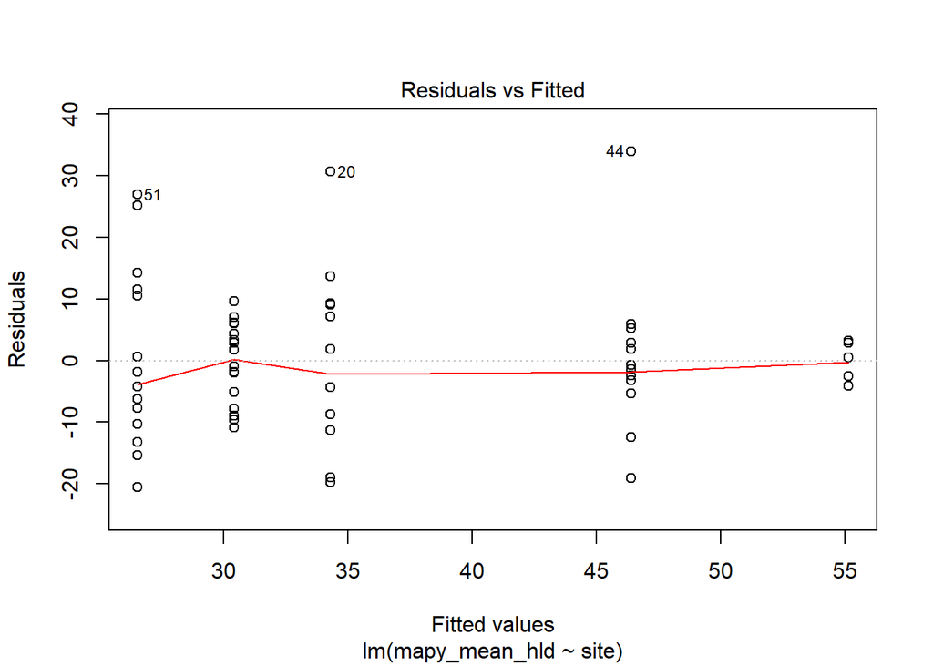

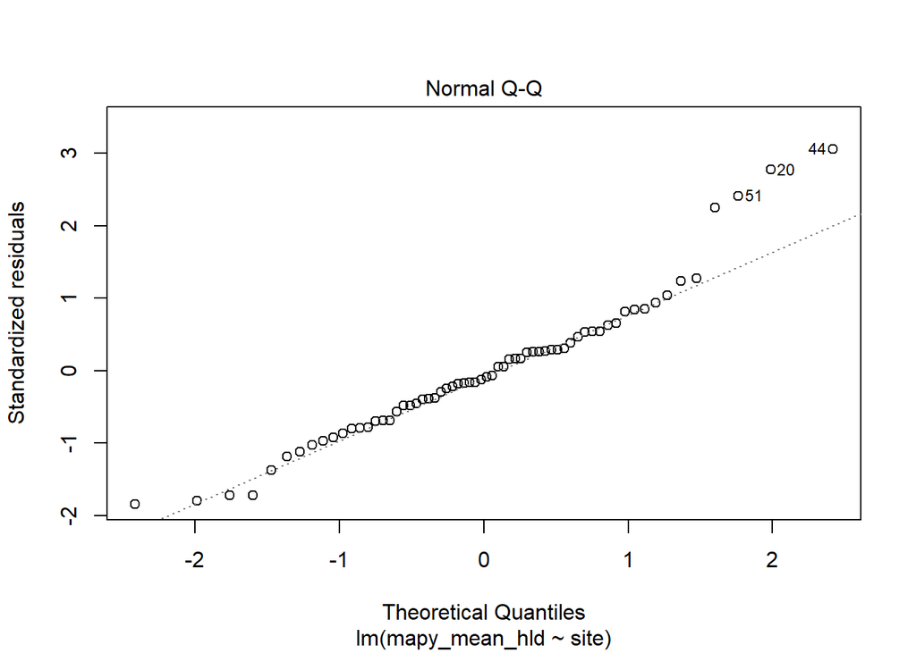

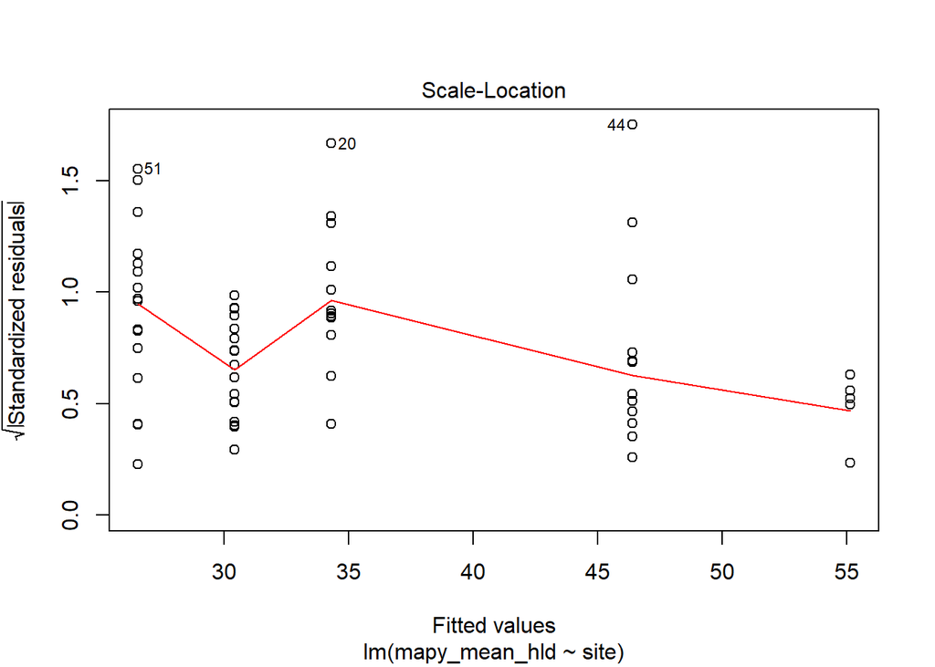

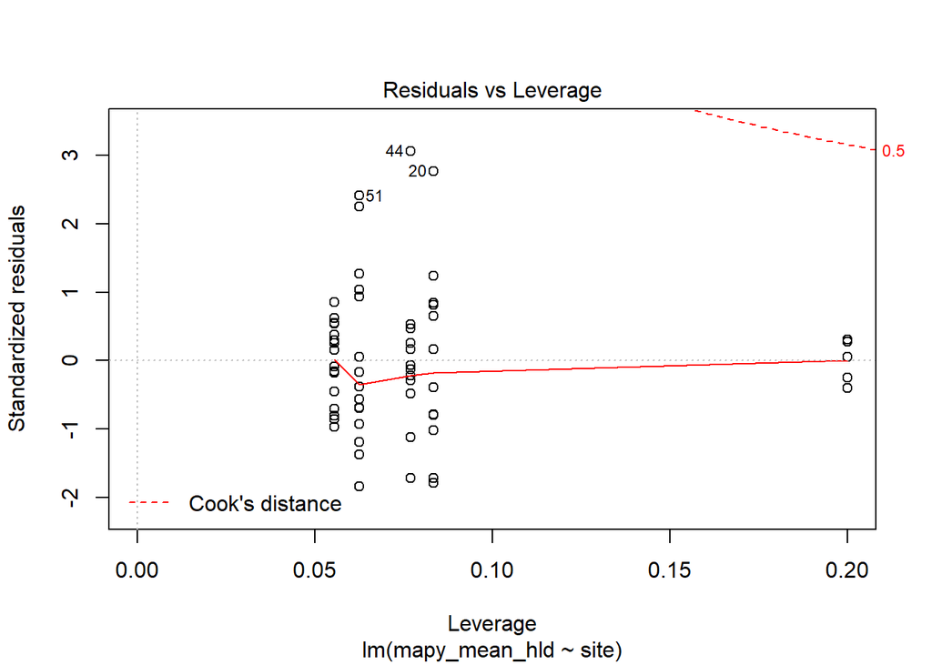

#### Model Selection: AIC

Backward model selection

```
## Start:  AIC=332.52
## mapy_mean_hld ~ site + urchin_presence + urchin_abundance + prev_mean_hld +
##     site:prev_mean_hld + mean_ammonia + mean_no2_no3 + mean_po4 +
##     mean_tchl + mean_pon + summer_mean_temp + summer_var_temp
##
##
## Step:  AIC=332.52
## mapy_mean_hld ~ site + urchin_abundance + prev_mean_hld + mean_ammonia +
##     mean_no2_no3 + mean_po4 + mean_tchl + mean_pon + summer_mean_temp +
##     summer_var_temp + site:prev_mean_hld
##
##                      Df Sum of Sq    RSS    AIC
## - site:prev_mean_hld  4   209.431 6791.1 326.53
## - summer_var_temp     1    13.507 6595.2 330.65
## - urchin_abundance    1    46.007 6627.7 330.97
## - mean_tchl           1   125.032 6706.7 331.73
## - mean_ammonia        1   141.743 6723.4 331.89
## - summer_mean_temp    1   157.543 6739.2 332.04
## - mean_pon            1   162.991 6744.7 332.09
## - mean_no2_no3        1   180.723 6762.4 332.26
## <none>                            6581.7 332.52
## - mean_po4            1   304.577 6886.3 333.42
##
## Step:  AIC=326.53
## mapy_mean_hld ~ site + urchin_abundance + prev_mean_hld + mean_ammonia +
##     mean_no2_no3 + mean_po4 + mean_tchl + mean_pon + summer_mean_temp +
##     summer_var_temp
##
##                    Df Sum of Sq    RSS    AIC
## - prev_mean_hld     1      4.20 6795.3 324.57
## - mean_ammonia      1     53.32 6844.4 325.03
## - summer_var_temp   1     58.15 6849.3 325.07
## - urchin_abundance  1     58.19 6849.3 325.07
## - mean_tchl         1    137.92 6929.0 325.81
## - mean_no2_no3      1    138.92 6930.0 325.82
## - summer_mean_temp  1    158.23 6949.3 326.00
## - mean_pon          1    192.86 6984.0 326.32
## <none>                          6791.1 326.53
## - mean_po4          1    298.98 7090.1 327.28
## - site              4   2542.59 9333.7 338.88
```

[output cut: 74 more lines]

```
##             Df Sum of Sq     RSS    AIC
## - mean_po4   1     135.0  7402.2 318.04
## <none>                    7267.2 318.86
## - mean_pon   1     494.4  7761.6 321.08
## - mean_tchl  1     531.6  7798.8 321.38
## - site       4    5582.8 12850.0 347.34
##
## Step:  AIC=318.04
## mapy_mean_hld ~ site + mean_tchl + mean_pon
##
##             Df Sum of Sq     RSS    AIC
## <none>                    7402.2 318.04
## - mean_pon   1     410.6  7812.8 319.50
## - mean_tchl  1     413.5  7815.7 319.52
## - site       4    5451.9 12854.1 345.36
```

Forward Model Selection

```
## Start:  AIC=342.52
## mapy_mean_hld ~ 1
##
##                    Df Sum of Sq     RSS    AIC
## + site              4    5237.2  7851.5 317.81
## + prev_mean_hld     1    1909.5 11179.1 334.43
## + urchin_abundance  1    1725.0 11363.6 335.47
## + mean_no2_no3      1     526.7 12562.0 341.89
## <none>                          13088.7 342.52
## + summer_var_temp   1     205.6 12883.1 343.51
## + summer_mean_temp  1     179.8 12908.8 343.63
## + mean_tchl         1      77.1 13011.5 344.14
## + mean_po4          1      36.2 13052.4 344.34
## + urchin_presence   1      16.2 13072.5 344.44
## + mean_ammonia      1       3.0 13085.6 344.50
## + mean_pon          1       1.5 13087.2 344.51
##
## Step:  AIC=317.81
## mapy_mean_hld ~ site
##
##                    Df Sum of Sq    RSS    AIC
## <none>                          7851.5 317.81
## + urchin_abundance  1   176.855 7674.6 318.35
## + mean_no2_no3      1   159.021 7692.4 318.50
## + summer_mean_temp  1   151.472 7700.0 318.57
## + mean_tchl         1    38.617 7812.8 319.50
## + mean_pon          1    35.797 7815.7 319.52
## + mean_po4          1    24.259 7827.2 319.61
## + prev_mean_hld     1    12.432 7839.0 319.71
## + summer_var_temp   1     4.235 7847.2 319.78
## + mean_ammonia      1     2.428 7849.0 319.79
```

Forward and backward selection produces different models, one with more than just the site variable.

```
##
## Call:
## lm(formula = mapy_mean_hld ~ site + mean_tchl + mean_pon, data = size_dat)
##
## Residuals:
##     Min      1Q  Median      3Q     Max
## -20.388  -7.715  -1.538   6.851  32.985
##
## Coefficients:
##             Estimate Std. Error t value Pr(>|t|)
## (Intercept)   21.663      8.957   2.419  0.01880 *
## siteAQUE      22.056      6.580   3.352  0.00143 **
## siteCARP      -8.774      4.731  -1.854  0.06885 .
## siteMOHK      12.082      4.564   2.647  0.01048 *
## siteNAPL      -2.388      4.349  -0.549  0.58503
## mean_tchl     -9.975      5.590  -1.784  0.07970 .
## mean_pon      14.496      8.152   1.778  0.08070 .
## ---
## Signif. codes:  0 '***' 0.001 '**' 0.01 '*' 0.05 '.' 0.1 ' ' 1
##
## Residual standard error: 11.4 on 57 degrees of freedom
## Multiple R-squared:  0.4345, Adjusted R-squared:  0.3749
## F-statistic: 7.298 on 6 and 57 DF,  p-value: 8.175e-06
```

```
## Analysis of Variance Table
##
## Model 1: mapy_mean_hld ~ 1
## Model 2: mapy_mean_hld ~ site
## Model 3: mapy_mean_hld ~ site + mean_tchl + mean_pon
##   Res.Df     RSS Df Sum of Sq       F    Pr(>F)
## 1     63 13088.7
## 2     59  7851.5  4    5237.2 10.0821 3.056e-06 ***
## 3     57  7402.2  2     449.2  1.7297    0.1865
## ---
## Signif. codes:  0 '***' 0.001 '**' 0.01 '*' 0.05 '.' 0.1 ' ' 1
```

The r-squared for the largest model is not much better than the models just looking at “site”, but the normality of residuals is better!

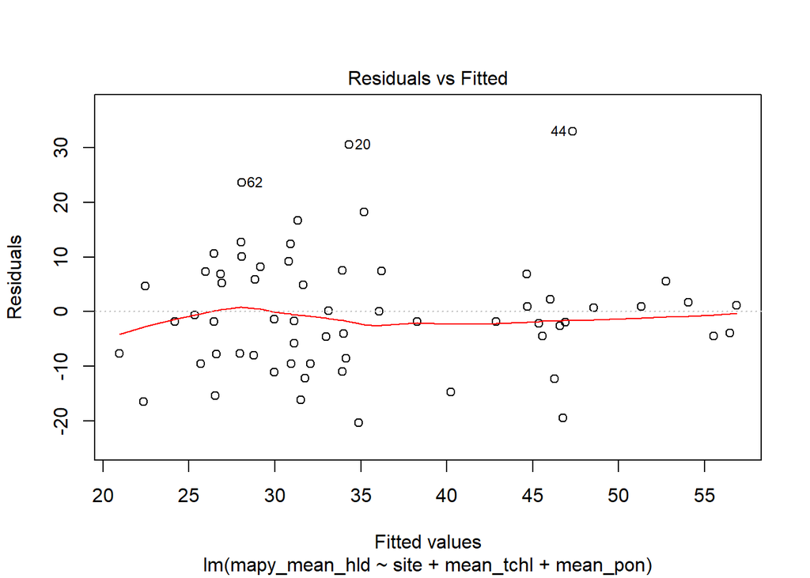

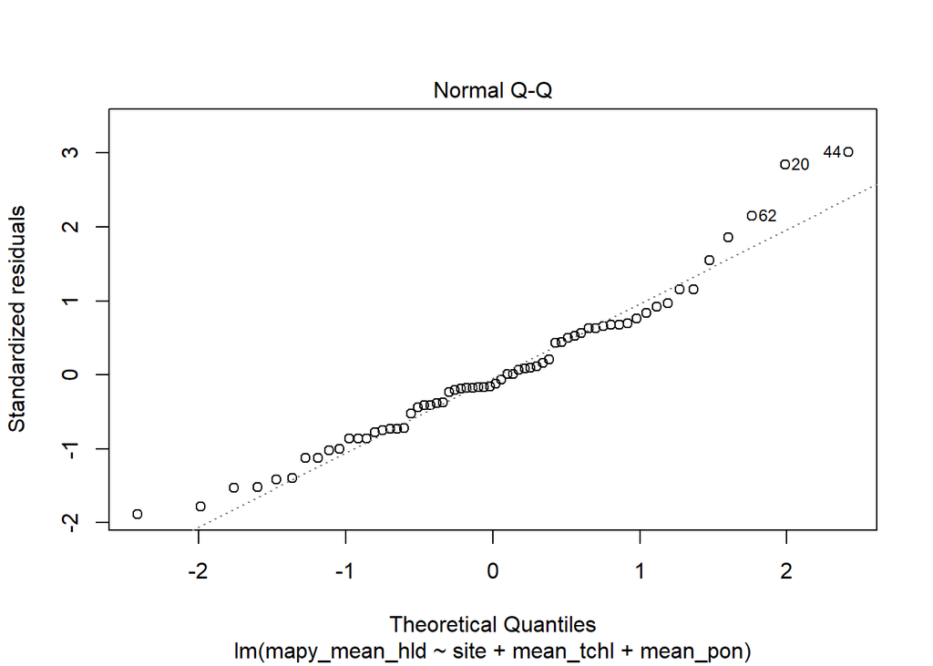

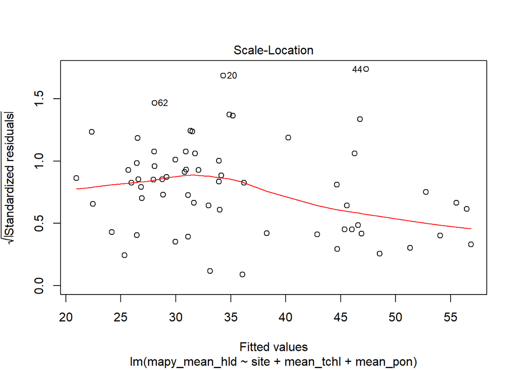

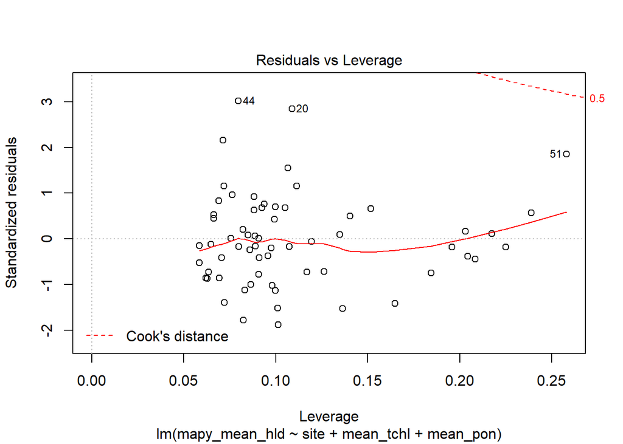

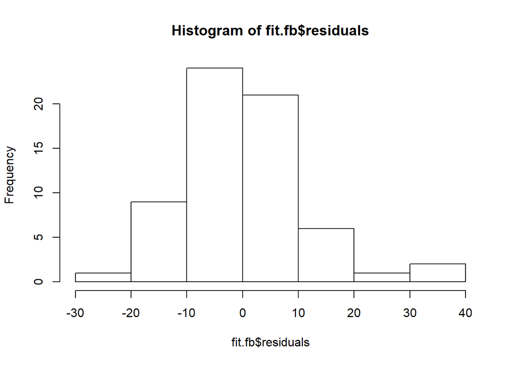